# Joins and imports: how to combine, import and export files in R. Factors and lists

Practical workbooks of Data Programming in Master in Computational Social Science (2024-2025)

Author

Javier Álvarez Liébana

## 1 Joins

When working with data we will not always have the information in a single table, and sometimes, we will be interested in **cross-referencing** information from different sources.

For this we will use a classic of every language that handles data: the famous **join**, a tool that will allow us to **cross one or several tables**, making use of a **identifying column** of each one of them.

```r
table_1 |>
  xxx_join(table_2, by = id)
```

- `inner_join()`: only **records with id in both** tables survive.
- `full_join()`: keeps **all records in both** tables.
- `left_join()`: keeps **all the records of the first table**, and looks for which ones have id also in the second one (in case of **not having it, it fills with NA** the fields of the 2nd table).
- `right_join()`: keeps **all records in the second table**, and searches which ones have id also in the first one.

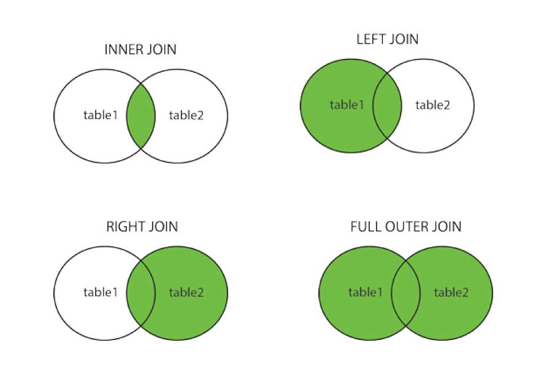

Let’s test the various joins with a simple example

```r
library(tidyverse)
tb_1 <- tibble("key" = 1:3, "val_x" = c("x1", "x2", "x3"))
tb_2 <- tibble("key" = c(1, 2, 4), "val_y" = c("y1", "y2", "y3"))
```

```r
tb_1
```

```
# A tibble: 3 × 2
    key val_x
  <int> <chr>
1     1 x1
2     2 x2
3     3 x3
```

```r
tb_2
```

```
# A tibble: 3 × 2
    key val_y
  <dbl> <chr>
1     1 y1
2     2 y2
3     4 y3
```

### 1.1 left_join()

Imagine that we want to **incorporate** to `tb_1` the **information from table_2**, identifying the records by the key column (`by = "key"`, the column it has to cross): we want to keep all the records of the first table and look for which ones have the same value in `key` also in the second one.

```r
tb_1 |>
  left_join(tb_2, by = "key")
```

```
# A tibble: 3 × 3
    key val_x val_y
  <dbl> <chr> <chr>
1     1 x1    y1
2     2 x2    y2
3     3 x3    <NA>
```

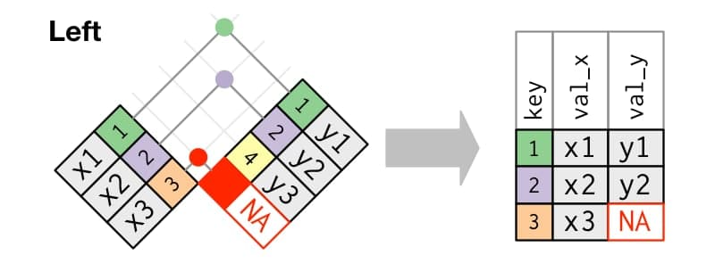

```r
tb_1 |>
  left_join(tb_2, by = "key")
```

```
# A tibble: 3 × 3
    key val_x val_y
  <dbl> <chr> <chr>
1     1 x1    y1
2     2 x2    y2
3     3 x3    <NA>
```

Notice that the **records in the first one whose key was not found in the second one** has given them the value of **absent**.

### 1.2 right_join()

```r
tb_1 |>
  right_join(tb_2, by = "key")
```

```
# A tibble: 3 × 3
    key val_x val_y
  <dbl> <chr> <chr>
1     1 x1    y1
2     2 x2    y2
3     4 <NA>  y3
```

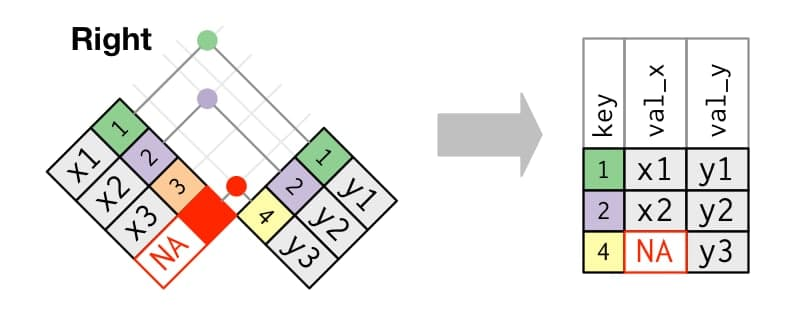

```r
tb_1 |>
  right_join(tb_2, by = "key")
```

```
# A tibble: 3 × 3
    key val_x val_y
  <dbl> <chr> <chr>
1     1 x1    y1
2     2 x2    y2
3     4 <NA>  y3
```

Notice that now the **records of the second one whose key was not found in the first one** are the ones given the value of **absent**.

### 1.3 keys and suffixes

The key columns we will use for the crossover **will not always be named the same**.

```r
tb_1 <- tibble("key_1" = 1:3, "val_x" = c("x1", "x2", "x3"))
tb_2 <- tibble("key_2" = c(1, 2, 4), "val_y" = c("y1", "y2", "y3"))
```

```r
# Left
tb_1  |>
  left_join(tb_2, by = c("key_1" = "key_2"))
```

```
# A tibble: 3 × 3
  key_1 val_x val_y
  <dbl> <chr> <chr>
1     1 x1    y1
2     2 x2    y2
3     3 x3    <NA>
```

```r
# Right
tb_1 |>
  right_join(tb_2, by = c("key_1" = "key_2"))
```

```
# A tibble: 3 × 3
  key_1 val_x val_y
  <dbl> <chr> <chr>
1     1 x1    y1
2     2 x2    y2
3     4 <NA>  y3
```

We can also **cross over several columns at the same time** (it will interpret as equal record the one that has the same set of keys), with `by = c("var1_t1" = "var1_t2", "var2_t1" = "var2_t2", ...)`. Let’s modify the previous example

```r
tb_1 <- tibble("k_11" = 1:3, "k_12" = c("a", "b", "c"),  "val_x" = c("x1", "x2", "x3"))
tb_2 <- tibble("k_21" = c(1, 2, 4), "k_22" = c("a", "b", "e"), "val_y" = c("y1", "y2", "y3"))
```

```r
# Left
tb_1 |>
  left_join(tb_2,
            by = c("k_11" = "k_21", "k_12" = "k_22"))
```

```
# A tibble: 3 × 4
   k_11 k_12  val_x val_y
  <dbl> <chr> <chr> <chr>
1     1 a     x1    y1
2     2 b     x2    y2
3     3 c     x3    <NA>
```

```r
# Right
tb_1 |>
  right_join(tb_2,
             by = c("k_11" = "k_21", "k_12" = "k_22"))
```

```
# A tibble: 3 × 4
   k_11 k_12  val_x val_y
  <dbl> <chr> <chr> <chr>
1     1 a     x1    y1
2     2 b     x2    y2
3     4 e     <NA>  y3
```

It could also happen that when crossing two tables, there are **columns of values named the same**

```r
tb_1 <- tibble("key_1" = 1:3, "val" = c("x1", "x2", "x3"))
tb_2 <- tibble("key_2" = c(1, 2, 4), "val" = c("y1", "y2", "y3"))
```

```r
# Left
tb_1 |>
  left_join(tb_2, by = c("key_1" = "key_2"))
```

```
# A tibble: 3 × 3
  key_1 val.x val.y
  <dbl> <chr> <chr>
1     1 x1    y1
2     2 x2    y2
3     3 x3    <NA>
```

Notice that **default adds the suffixes** `.x` and `.y` to tell us which table they come from. This **suffix can be specified** in the optional argument `suffix = ...`, which allows us to **distinguish the variables** of one table from another.

```r
# Left
tb_1 |>
  left_join(tb_2, by = c("key_1" = "key_2"),
            suffix = c("_table1", "_table2"))
```

```
# A tibble: 3 × 3
  key_1 val_table1 val_table2
  <dbl> <chr>      <chr>
1     1 x1         y1
2     2 x2         y2
3     3 x3         <NA>
```

### 1.4 full_join()

The two previous cases form what is known as **outer joins**: crosses where observations are kept that appear in at least one table. The third outer join is known as `full_join()` which will **keep observations from both** tables, **adding rows** that do not match the other table.

```r
tb_1  |>
  full_join(tb_2, by = c("key_1" = "key_2"))
```

```
# A tibble: 4 × 3
  key_1 val.x val.y
  <dbl> <chr> <chr>
1     1 x1    y1
2     2 x2    y2
3     3 x3    <NA>
4     4 <NA>  y3
```

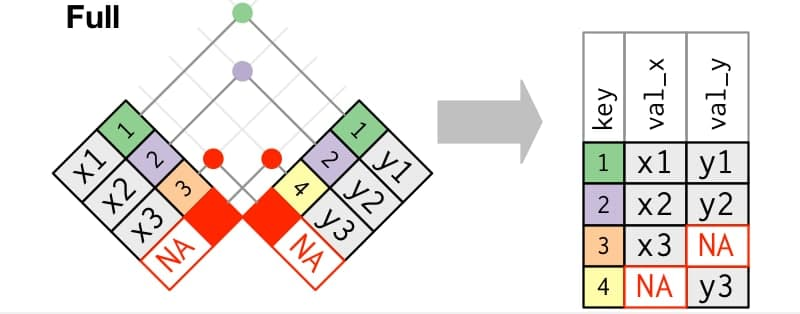

### 1.5 inner_join()

Opposite the outer join is what is known as **inner join**, with `inner_join()`: a join in which only the **observations that appear in both tables** are kept, only those records that are patched are kept.

```r
tb_1 |>
  inner_join(tb_2,  by = c("key_1" = "key_2"))
```

```
# A tibble: 2 × 3
  key_1 val.x val.y
  <dbl> <chr> <chr>
1     1 x1    y1
2     2 x2    y2
```

Note that in terms of records, `inner_join` if it is commutative, **we don’t care about the order of the tables**: the only thing that changes is the order of the columns it adds.

```r
tb_1 |>
  inner_join(tb_2, by = c("key_1" = "key_2"))
```

```
# A tibble: 2 × 3
  key_1 val.x val.y
  <dbl> <chr> <chr>
1     1 x1    y1
2     2 x2    y2
```

```r
tb_2 |> inner_join(tb_1, by = c("key_2" = "key_1"))
```

```
# A tibble: 2 × 3
  key_2 val.x val.y
  <dbl> <chr> <chr>
1     1 y1    x1
2     2 y2    x2
```

### 1.6 semi/anti_join()

Finally we have two interesting tools to **filter (not cross) records**: `semi_join()` and `anti_join()`. The **semi join** leaves us in the **first table the records whose key is also in the second table** (like an inner join but without adding the info from the second table). And the second one, the anti join, does just the opposite (those that are not).

```r
# semijoin
tb_1 |>
  semi_join(tb_2, by = c("key_1" = "key_2"))
```

```
# A tibble: 2 × 2
  key_1 val
  <int> <chr>
1     1 x1
2     2 x2
```

```r
# antijoin
tb_1 |>
  anti_join(tb_2, by = c("key_1" = "key_2"))
```

```
# A tibble: 1 × 2
  key_1 val
  <int> <chr>
1     3 x3
```

### 1.7 💻 It’s your turn

For the exercises we will use the tables available in the package `{nycflights13}`.

```r
library(nycflights13)
```

- **airlines**: name of airlines (with their abbreviation).
- **airports**: airport data (names, longitude, latitude, altitude, etc).
- **flights**, **planes**: flight and aircraft data.
- **weather**: hourly weather data.

**Exercise 1**

📝 From package `{nycflights13}` incorporates into the `flights` table the airline data in `airlines`. We want to maintain all flight records, adding the airline information to the airlines table.

```r
flights_airlines <-
  flights |>
  left_join(airlines, by = "carrier")
flights_airlines
```

**Exercise 2**

📝 To the table obtained from the crossing of the previous section, include the data of the aircraft in `planes`, but including only those flights for which we have information on their aircraft (and vice versa).

```r
flights_airlines_planes <-
  flights_airlines |>
  inner_join(planes, by = "tailnum")
flights_airlines_planes
```

**Exercise 3**

📝 Repeat the previous exercise but keeping both `year` variables (in one is the year of flight, in the other is the year of construction of the aircraft), and distinguishing them from each other

```r
flights_airlines_planes <-
  flights_airlines |>
  inner_join(planes, by = "tailnum",
             suffix = c("_flight", "_build_aircraft"))
flights_airlines_planes
```

**Exercise 4**

📝 To the table obtained from the previous exercise includes the longitude and latitude of the airports in `airports`, distinguishing between the latitude/longitude of the airport at destination and at origin.

```r
flights_airlines_planes |>
  left_join(airports |> select(faa, lat, lon),
            by = c("origin" = "faa")) |>
  rename(lat_origin = lat, lon_origin = lon) |>
  left_join(airports |> select(faa, lat, lon),
            by = c("dest" = "faa")) |>
  rename(lat_dest = lat, lon_dest = lon)
```

**Exercise 5**

📝 Filter from `airports` only those airports from which flights depart. Repeat the process filtering only those airports where flights arrive.

```r
airports |>
  semi_join(flights, by = c("faa" = "origin"))
airports |>
  semi_join(flights, by = c("faa" = "dest"))
```

**Exercise 6**

📝 How many flights do we not have information about the aircraft? Eliminate flights that do not have an aircraft ID (other than NA) beforehand.

```r
flights |>
  drop_na(tailnum) |>
  anti_join(planes, by = "tailnum") |>
  count(tailnum, sort = TRUE)
```

## 2 🐣 Case study I: Beatles and Rolling Stones

We will use to practice simple joins the `band_members` and `band_instruments` datasets already included in the `{dplyr}` package.

```r
library(dplyr)
band_members
```

```
# A tibble: 3 × 2
  name  band
  <chr> <chr>
1 Mick  Stones
2 John  Beatles
3 Paul  Beatles
```

```r
band_instruments
```

```
# A tibble: 3 × 2
  name  plays
  <chr> <chr>
1 John  guitar
2 Paul  bass
3 Keith guitar
```

In the first one we have a series of artists and the band they belong to; in the second one we have a series of artists and the instrument they play. Beyond performing the requested actions, try to visualize which final table you would have

### 2.1 Question 1

> Given the table `band_members`, incorporate the information of what instrument each member plays (`band_instruments`) of the ones you have in that table.

```r
left_join_band <-
  band_members |>
  left_join(band_instruments, by = "name")
```

### 2.2 Question 2

> Given the `band_members` and `band_instruments` tables, what kind of join should you do to have a complete table, with no absentees, where all band members have their instrument information, and every instrument has a member associated with it?

```r
inner_join_band <-
  band_members |>
  inner_join(band_instruments, by = "name")
```

### 2.3 Question 3

> Given the `band_instruments` table, how to incorporate the information of who plays each instrument (in case we know it)?

```r
right_join_band <-
  band_members |>
  right_join(band_instruments, by = "name")

# other option
left_join_instruments <-
  band_instruments |>
  left_join(band_members, by = "name")
```

### 2.4 Question 4

> Given the `band_members` and `band_instruments` tables, what kind of join should you do to have a table with all the info, both members and instruments, even if there are members whose instrument you do not know, and instruments whose carrier you do not know?

```r
full_join_band <-
  band_members |>
  full_join(band_instruments, by = "name")
```

## 3 🐣 Case study II: income by municipalities

In the file `municipios.csv` we have stored the information of the municipalities of Spain as of 2019.

```r
# 2019 data
mun_data <- read_csv(file = "./datos/municipios.csv")
```

On the other hand, in the file `renta_mun` we have the average per capita income of each administrative unit (municipalities, districts, provinces, autonomous communities,…) for different years.

```r
renta_mun <- read_csv(file = "./datos/renta_mun.csv")
```

Before we start let’s **normalize variable names** using `clean_names()` from the `{janitor}` package.

```r
mun_data <-
  mun_data |>
  janitor::clean_names()
renta_mun <-
  renta_mun |>
  janitor::clean_names()
```

### 3.1 Question 1

> Convert to tidydata `renta_mun` obtaining a table of 4 columns: `unit`, `year`, `income` and `codigo_ine` (no absent and each data of the correct type)

```r
renta_mun_tidy <-
  renta_mun |>
  pivot_longer(cols = contains("x"), names_to = "year",
               values_to = "income", names_prefix = "x",
               names_transform = list(year = as.numeric),
               values_drop_na = TRUE)
```

### 3.2 Question 2

> If you look at the table above we have data from different administrative units that are not always municipalities. Knowing that all municipalities have a 5-character code, filter only those records that correspond to municipal units.

```r
renta_mun_tidy <-
  renta_mun_tidy |>
  filter(str_detect(codigo_ine, pattern = "[0-9]{5}") &
           str_length(codigo_ine) == 5)
```

### 3.3 Question 3

> Then properly separate the unit variable into two columns: one with the code (which you already have so one of the two should be removed) and the name. Remove any remaining spaces (take a look at the `{stringr}` package options).

```r
renta_mun_tidy <-
  renta_mun_tidy |>
  separate(col = "unidad", into = c("cod_rm", "name"), sep = 5) |>
  select(-cod_rm) |>
  mutate(name = str_trim(name))
```

### 3.4 Question 4

> In which year was the median income higher? And lower? What was the median income of municipalities in Spain in 2019?

```r
summary_renta <-
  renta_mun_tidy |>
  summarise("mean_income" = mean(income, na.rm = TRUE),
            .by = year)
summary_renta |>
  slice_min(mean_income, n = 1)
```

```
# A tibble: 1 × 2
   year mean_income
  <dbl>       <dbl>
1  2015      10083.
```

```r
summary_renta |>
  slice_max(mean_income, n = 1)
```

```
# A tibble: 1 × 2
   year mean_income
  <dbl>       <dbl>
1  2019      11672.
```

```r
renta_mun_tidy |>
  filter(year == 2019) |>
  summarise("median_income" = median(income, na.rm = TRUE))
```

```
# A tibble: 1 × 1
  median_income
          <dbl>
1         11462
```

### 3.5 Question 5

> Do whatever you consider to obtain the province with the highest average income in 2019 and the one with the lowest. Be sure to get its name.

```r
summary_by_prov <-
  renta_mun_tidy |>
  filter(year == 2019) |>
  left_join(mun_data, by = "codigo_ine", suffix = c("", "_rm")) |>
  select(-contains("rm")) |>
  summarise("mean_by_prov" = mean(income, na.rm = TRUE),
            .by = c("cpro", "ine_prov_name"))

summary_by_prov |>
  slice_max(mean_by_prov, n = 1)
```

```
# A tibble: 1 × 3
  cpro  ine_prov_name mean_by_prov
  <chr> <chr>                <dbl>
1 20    Gipuzkoa            15890.
```

```r
summary_by_prov |>
  slice_min(mean_by_prov, n = 1)
```

```
# A tibble: 1 × 3
  cpro  ine_prov_name mean_by_prov
  <chr> <chr>                <dbl>
1 06    Badajoz              8805.
```

### 3.6 Question 6

> Obtain from each ccaa the name of the municipality with the highest income in 2019.

```r
renta_mun_tidy |>
  filter(year == 2019) |>
  left_join(mun_data, by = "codigo_ine", suffix = c("", "_rm")) |>
  select(-contains("rm")) |>
  slice_max(income, by = "codauto")
```

```
# A tibble: 19 × 10
   name  codigo_ine  year income codauto ine_ccaa_name cpro  ine_prov_name cmun
   <chr> <chr>      <dbl>  <dbl> <chr>   <chr>         <chr> <chr>         <chr>
 1 Nava… 40904       2019  20242 07      Castilla y L… 40    Segovia       904
 2 Alma… 10019       2019  13940 11      Extremadura   10    Cáceres       019
 3 Olei… 15058       2019  16447 12      Galicia       15    Coruña, A     058
 4 Lauk… 48053       2019  21672 16      País Vasco    48    Bizkaia       053
 5 Lumb… 26091       2019  24007 17      Rioja, La     26    Rioja, La     091
 6 Murc… 30030       2019  11631 14      Murcia, Regi… 30    Murcia        030
 7 Raja… 08178       2019  23401 09      Cataluña      08    Barcelona     178
 8 Aloc… 19023       2019  19700 08      Castilla - L… 19    Guadalajara   023
 9 Argu… 22037       2019  19219 02      Aragón        22    Huesca        037
10 Alcu… 04009       2019  14196 01      Andalucía     04    Almería       009
11 Aran… 31023       2019  15517 15      Navarra, Com… 31    Navarra       023
12 Sant… 35021       2019  15982 05      Canarias      35    Palmas, Las   021
13 Roca… 46216       2019  17872 10      Comunitat Va… 46    Valencia/Val… 216
14 Pozu… 28115       2019  26367 13      Madrid, Comu… 28    Madrid        115
15 Vall… 07063       2019  19565 04      Balears, Ill… 07    Balears, Ill… 063
16 Vald… 39093       2019  15574 06      Cantabria     39    Cantabria     093
17 Teve… 33072       2019  15409 03      Asturias, Pr… 33    Asturias      072
18 Ceuta 51001       2019  12038 18      Ceuta         51    Ceuta         001
19 Meli… 52001       2019  11463 19      Melilla       52    Melilla       001
# ℹ 1 more variable: lau_code <chr>
```

## 4 Import and export files

So far we have only used data already loaded in packages but many times **we will need to import data externally**. One of the main **strengths** of `R` is that we can import data very easily in different formats:

- **R native formats**: `.rda`, `.RData` and `.rds` formats.
- **Rectangular (tabular) data**: `.csv` and `.tsv` formats
- **Untabulated data**: `.txt` format.
- **Data in excel**: `.xls` and `.xlsx` formats
- **Data from SAS/Stata/SPSS**: `.sas7bdat`, `.sav` and `.dat` formats
- **Data from Google Drive**
- **Data from API’s**: aemet, catastro, twitter, spotify, etc.

### 4.1 R native formats

The **simplest** files to import into `R` (and which usually take up less disk space) are its own **native extensions**: files in `.RData`, `.rda` and `.rds` formats. To load the former we simply need to **use the native** function `load()` by providing it the file path.

- `RData` file: we are going to import the file `world_bank_pop.RData`, which includes the dataset `world_bank_pop`

```r
load("./datos/world_bank_pop.RData")
world_bank_pop
```

```
# A tibble: 1,064 × 20
   country indicator      `2000`  `2001`  `2002`  `2003`  `2004`  `2005`  `2006`
   <chr>   <chr>           <dbl>   <dbl>   <dbl>   <dbl>   <dbl>   <dbl>   <dbl>
 1 ABW     SP.URB.TOTL    4.16e4 4.20e+4 4.22e+4 4.23e+4 4.23e+4 4.24e+4 4.26e+4
 2 ABW     SP.URB.GROW    1.66e0 9.56e-1 4.01e-1 1.97e-1 9.46e-2 1.94e-1 3.67e-1
 3 ABW     SP.POP.TOTL    8.91e4 9.07e+4 9.18e+4 9.27e+4 9.35e+4 9.45e+4 9.56e+4
 4 ABW     SP.POP.GROW    2.54e0 1.77e+0 1.19e+0 9.97e-1 9.01e-1 1.00e+0 1.18e+0
 5 AFE     SP.URB.TOTL    1.16e8 1.20e+8 1.24e+8 1.29e+8 1.34e+8 1.39e+8 1.44e+8
 6 AFE     SP.URB.GROW    3.60e0 3.66e+0 3.72e+0 3.71e+0 3.74e+0 3.81e+0 3.81e+0
 7 AFE     SP.POP.TOTL    4.02e8 4.12e+8 4.23e+8 4.34e+8 4.45e+8 4.57e+8 4.70e+8
 8 AFE     SP.POP.GROW    2.58e0 2.59e+0 2.61e+0 2.62e+0 2.64e+0 2.67e+0 2.70e+0
 9 AFG     SP.URB.TOTL    4.31e6 4.36e+6 4.67e+6 5.06e+6 5.30e+6 5.54e+6 5.83e+6
10 AFG     SP.URB.GROW    1.86e0 1.15e+0 6.86e+0 7.95e+0 4.59e+0 4.47e+0 5.03e+0
# ℹ 1,054 more rows
# ℹ 11 more variables: `2007` <dbl>, `2008` <dbl>, `2009` <dbl>, `2010` <dbl>,
#   `2011` <dbl>, `2012` <dbl>, `2013` <dbl>, `2014` <dbl>, `2015` <dbl>,
#   `2016` <dbl>, `2017` <dbl>
```

- `.rda` file: we will import the airquality dataset from `airquality.rda`

```r
load("./datos/airquality.rda")
airquality |> as_tibble()
```

```
# A tibble: 153 × 6
   Ozone Solar.R  Wind  Temp Month   Day
   <int>   <int> <dbl> <int> <int> <int>
 1    41     190   7.4    67     5     1
 2    36     118   8      72     5     2
 3    12     149  12.6    74     5     3
 4    18     313  11.5    62     5     4
 5    NA      NA  14.3    56     5     5
 6    28      NA  14.9    66     5     6
 7    23     299   8.6    65     5     7
 8    19      99  13.8    59     5     8
 9     8      19  20.1    61     5     9
10    NA     194   8.6    69     5    10
# ℹ 143 more rows
```

Note that files loaded with `load()` are **automatically loaded into the environment** (with the originally saved name), and not only datasets can be loaded: `load()` allows us to load multiple objetcs (not only a tabular data)

Native `.rda` and `.RData` files are a properly way to save your environment.

```r
load(file = "./datos/multiple_objects.rda")
```

- `.rds` files: for this type we must use `readRDS()`, and we need to incorporate a **argument `file`** with the path. In this case we are going to import **lung cancer data** from the North Central Cancer Treatment Group. Note that now **.rds import files are a unique database**

```r
lung_cancer <-
  readRDS(file = "./datos/NCCTG_lung_cancer.rds") |>
  as_tibble()
lung_cancer
```

```
# A tibble: 228 × 10
    inst  time status   age   sex ph.ecog ph.karno pat.karno meal.cal wt.loss
   <dbl> <dbl>  <dbl> <dbl> <dbl>   <dbl>    <dbl>     <dbl>    <dbl>   <dbl>
 1     3   306      2    74     1       1       90       100     1175      NA
 2     3   455      2    68     1       0       90        90     1225      15
 3     3  1010      1    56     1       0       90        90       NA      15
 4     5   210      2    57     1       1       90        60     1150      11
 5     1   883      2    60     1       0      100        90       NA       0
 6    12  1022      1    74     1       1       50        80      513       0
 7     7   310      2    68     2       2       70        60      384      10
 8    11   361      2    71     2       2       60        80      538       1
 9     1   218      2    53     1       1       70        80      825      16
10     7   166      2    61     1       2       70        70      271      34
# ℹ 218 more rows
```

**Important**

The **paths** must always be **without spaces, ñ, or accents**.

### 4.2 Tabular data: readr

The `{readr}` package within the `{tidyverse}` environment contains several useful functions for **loading rectangular data (without formatting)**.

- `read_csv()`: `.csv` files whose **separator is comma**
- `read_csv2()`: **semicolon**
- `read_tsv()`: **tabulator**.
- `read_table()`: **space**.
- `read_delim()`: generic function for **character delimited files**.

All of them need as **argument the file path** plus **other optional** (skip header or not, decimals, etc). See more at https://readr.tidyverse.org/

#### 4.2.1 .csv, .tsv

The main advantage of `{readr}` is that it **automates formatting** to go from a flat (unformatted) file to a tibble (in rows and columns, with formatting).

- File `.csv`: with `read_csv()` we will load **comma separated** files, passing as **argument the path** in `file = ...`. Let’s import the `chickens.csv` dataset (about cartoon chickens, why not). If you look at the output it gives us the type of variables.

```r
library(readr)
chickens <- read_csv(file = "./datos/chickens.csv")
chickens
```

```
# A tibble: 5 × 4
  chicken                 sex     eggs_laid motto
  <chr>                   <chr>       <dbl> <chr>
1 Foghorn Leghorn         rooster         0 That's a joke, ah say, that's a jok…
2 Chicken Little          hen             3 The sky is falling!
3 Ginger                  hen            12 Listen. We'll either die free chick…
4 Camilla the Chicken     hen             7 Bawk, buck, ba-gawk.
5 Ernie The Giant Chicken rooster         0 Put Captain Solo in the cargo hold.
```

The **variable format** will normally be done **automatically** by `read_csv()`, and we can query it with `spec()`.

```r
spec(chickens)
```

Although it usually does it well automatically we can **specify the format explicitly** in `col_types = list()` (in list format, with `col_xxx()` for each type of variable, for example `eggs_laid` will be imported as character).

```r
chickens <-
  read_csv(file = "./datos/chickens.csv",
           col_types = list(col_character(), col_character(),
                            col_character(), col_character()))
chickens
```

```
# A tibble: 5 × 4
  chicken                 sex     eggs_laid motto
  <chr>                   <chr>   <chr>     <chr>
1 Foghorn Leghorn         rooster 0         That's a joke, ah say, that's a jok…
2 Chicken Little          hen     3         The sky is falling!
3 Ginger                  hen     12        Listen. We'll either die free chick…
4 Camilla the Chicken     hen     7         Bawk, buck, ba-gawk.
5 Ernie The Giant Chicken rooster 0         Put Captain Solo in the cargo hold.
```

We can even indicate that **variables we want to select** (without occupying memory), by indicating it in `col_select = ...` (in list format, with `col_select = ...`).

```r
chickens <-
  read_csv(file = "./datos/chickens.csv",
           col_select = c(chicken, sex, eggs_laid))
chickens
```

```
# A tibble: 5 × 3
  chicken                 sex     eggs_laid
  <chr>                   <chr>       <dbl>
1 Foghorn Leghorn         rooster         0
2 Chicken Little          hen             3
3 Ginger                  hen            12
4 Camilla the Chicken     hen             7
5 Ernie The Giant Chicken rooster         0
```

#### 4.2.2 .txt

What happens when the **separator is not correct**?

If we use `read_csv()` it expects the separator between columns to be a comma but, as you can see with the following `.txt`, it interprets everything as a single column: **has no comma and does not know where to separate**

```r
datos_txt <- read_csv(file = "./datos/massey-rating.txt")
dim(datos_txt)
```

```
[1] 10  1
```

```r
as_tibble(datos_txt)
```

```
# A tibble: 10 × 1
   `UCC PAY LAZ KPK  RT   COF BIH DII ENG ACU Rank Team            Conf`
   <chr>
 1 1   1   1   1   1     1   1   1   1   1    1 Ohio St          B10
 2 2   2   2   2   2     2   2   2   4   2    2 Oregon           P12
 3 3   4   3   4   3     4   3   4   2   3    3 Alabama          SEC
 4 4   3   4   3   4     3   5   3   3   4    4 TCU              B12
 5 6   6   6   5   5     7   6   5   6  11    5 Michigan St      B10
 6 7   7   7   6   7     6  11   8   7   8    6 Georgia          SEC
 7 5   5   5   7   6     8   4   6   5   5    7 Florida St       ACC
 8 8   8   9   9  10     5   7   7  10   7    8 Baylor           B12
 9 9  11   8  13  11    11  12   9  14   9    9 Georgia Tech     ACC
10 13  10  13  11   8     9  10  11   9  10   10 Mississippi      SEC
```

To do this we have.

- `read_csv2()` when the **separator is semicolon**, `read_tsv()` when the **is a tab** and `read_table()` when the **is a space**.
- `read_delim()` in general.

```r
datos_txt <- read_table(file = "./datos/massey-rating.txt")
as_tibble(datos_txt)
```

```
# A tibble: 10 × 13
     UCC   PAY   LAZ   KPK    RT   COF   BIH   DII   ENG   ACU  Rank Team  Conf
   <dbl> <dbl> <dbl> <dbl> <dbl> <dbl> <dbl> <dbl> <dbl> <dbl> <dbl> <chr> <chr>
 1     1     1     1     1     1     1     1     1     1     1     1 Ohio  St
 2     2     2     2     2     2     2     2     2     4     2     2 Oreg… P12
 3     3     4     3     4     3     4     3     4     2     3     3 Alab… SEC
 4     4     3     4     3     4     3     5     3     3     4     4 TCU   B12
 5     6     6     6     5     5     7     6     5     6    11     5 Mich… St
 6     7     7     7     6     7     6    11     8     7     8     6 Geor… SEC
 7     5     5     5     7     6     8     4     6     5     5     7 Flor… St
 8     8     8     9     9    10     5     7     7    10     7     8 Bayl… B12
 9     9    11     8    13    11    11    12     9    14     9     9 Geor… Tech
10    13    10    13    11     8     9    10    11     9    10    10 Miss… SEC
```

### 4.3 Excel data (.xls, .xlsx)

Another key import package will be the `{readxl}` package for **importing data from Excel**. Three functions will be key:

- `read_xls()` specific to `.xls`, `read_xlsx()` specific to `.xlsx`.
- `read_excel()`: for both `.xls` and `.xlsx`.

We are going to import `deaths.xlsx` with celebrity death records.

```r
library(readxl)
deaths <- read_xlsx(path = "./datos/deaths.xlsx")
deaths
```

```
# A tibble: 18 × 6
   `Lots of people`             ...2                     ...3  ...4  ...5  ...6
   <chr>                        <chr>                    <chr> <chr> <chr> <chr>
 1 simply cannot resist writing <NA>                     <NA>  <NA>  <NA>  some…
 2 at                           the                      top   <NA>  of    thei…
 3 or                           merging                  <NA>  <NA>  <NA>  cells
 4 Name                         Profession               Age   Has … Date… Date…
 5 David Bowie                  musician                 69    TRUE  17175 42379
 6 Carrie Fisher                actor                    60    TRUE  20749 42731
 7 Chuck Berry                  musician                 90    TRUE  9788  42812
 8 Bill Paxton                  actor                    61    TRUE  20226 42791
 9 Prince                       musician                 57    TRUE  21343 42481
10 Alan Rickman                 actor                    69    FALSE 16854 42383
11 Florence Henderson           actor                    82    TRUE  12464 42698
12 Harper Lee                   author                   89    FALSE 9615  42419
13 Zsa Zsa Gábor                actor                    99    TRUE  6247  42722
14 George Michael               musician                 53    FALSE 23187 42729
15 Some                         <NA>                     <NA>  <NA>  <NA>  <NA>
16 <NA>                         also like to write stuff <NA>  <NA>  <NA>  <NA>
17 <NA>                         <NA>                     at t… bott… <NA>  <NA>
18 <NA>                         <NA>                     <NA>  <NA>  <NA>  too!
```

```r
deaths |> slice(1:6)
```

```
# A tibble: 6 × 6
  `Lots of people`             ...2       ...3  ...4     ...5          ...6
  <chr>                        <chr>      <chr> <chr>    <chr>         <chr>
1 simply cannot resist writing <NA>       <NA>  <NA>     <NA>          some not…
2 at                           the        top   <NA>     of            their sp…
3 or                           merging    <NA>  <NA>     <NA>          cells
4 Name                         Profession Age   Has kids Date of birth Date of …
5 David Bowie                  musician   69    TRUE     17175         42379
6 Carrie Fisher                actor      60    TRUE     20749         42731
```

One thing that is **very common misfortune** is that there is some kind of comment or text at the beginning of the file, having to **skip those rows**.

We can **skip these rows** directly in the load with `skip = ...` (indicating the number of rows to skip).

```r
deaths <- read_xlsx(path = "./datos/deaths.xlsx", skip = 4)
deaths
```

```
# A tibble: 14 × 6
   Name          Profession Age   `Has kids` `Date of birth`     `Date of death`
   <chr>         <chr>      <chr> <chr>      <dttm>              <chr>
 1 David Bowie   musician   69    TRUE       1947-01-08 00:00:00 42379
 2 Carrie Fisher actor      60    TRUE       1956-10-21 00:00:00 42731
 3 Chuck Berry   musician   90    TRUE       1926-10-18 00:00:00 42812
 4 Bill Paxton   actor      61    TRUE       1955-05-17 00:00:00 42791
 5 Prince        musician   57    TRUE       1958-06-07 00:00:00 42481
 6 Alan Rickman  actor      69    FALSE      1946-02-21 00:00:00 42383
 7 Florence Hen… actor      82    TRUE       1934-02-14 00:00:00 42698
 8 Harper Lee    author     89    FALSE      1926-04-28 00:00:00 42419
 9 Zsa Zsa Gábor actor      99    TRUE       1917-02-06 00:00:00 42722
10 George Micha… musician   53    FALSE      1963-06-25 00:00:00 42729
11 Some          <NA>       <NA>  <NA>       NA                  <NA>
12 <NA>          also like… <NA>  <NA>       NA                  <NA>
13 <NA>          <NA>       at t… bottom,    NA                  <NA>
14 <NA>          <NA>       <NA>  <NA>       NA                  too!
```

In addition with `col_names = ...` we can already rename the columns in the import (if **provide names assumes 1st line already as a data**)

```r
deaths <-
  read_xlsx(path = "./datos/deaths.xlsx", skip = 5,
            col_names = c("name", "profession", "age", "kids", "birth", "death"))
deaths
```

```
# A tibble: 14 × 6
   name               profession           age   kids  birth               death
   <chr>              <chr>                <chr> <chr> <dttm>              <chr>
 1 David Bowie        musician             69    TRUE  1947-01-08 00:00:00 42379
 2 Carrie Fisher      actor                60    TRUE  1956-10-21 00:00:00 42731
 3 Chuck Berry        musician             90    TRUE  1926-10-18 00:00:00 42812
 4 Bill Paxton        actor                61    TRUE  1955-05-17 00:00:00 42791
 5 Prince             musician             57    TRUE  1958-06-07 00:00:00 42481
 6 Alan Rickman       actor                69    FALSE 1946-02-21 00:00:00 42383
 7 Florence Henderson actor                82    TRUE  1934-02-14 00:00:00 42698
 8 Harper Lee         author               89    FALSE 1926-04-28 00:00:00 42419
 9 Zsa Zsa Gábor      actor                99    TRUE  1917-02-06 00:00:00 42722
10 George Michael     musician             53    FALSE 1963-06-25 00:00:00 42729
11 Some               <NA>                 <NA>  <NA>  NA                  <NA>
12 <NA>               also like to write … <NA>  <NA>  NA                  <NA>
13 <NA>               <NA>                 at t… bott… NA                  <NA>
14 <NA>               <NA>                 <NA>  <NA>  NA                  too!
```

Sometimes **Excel dates are incorrectly formatted** (surprise): we can use `convertToDate()` from the `{openxlsx}` package to convert it.

```r
library(openxlsx)
deaths$death <- convertToDate(deaths$death)
deaths
```

```
# A tibble: 14 × 6
   name               profession      age   kids  birth               death
   <chr>              <chr>           <chr> <chr> <dttm>              <date>
 1 David Bowie        musician        69    TRUE  1947-01-08 00:00:00 2016-01-10
 2 Carrie Fisher      actor           60    TRUE  1956-10-21 00:00:00 2016-12-27
 3 Chuck Berry        musician        90    TRUE  1926-10-18 00:00:00 2017-03-18
 4 Bill Paxton        actor           61    TRUE  1955-05-17 00:00:00 2017-02-25
 5 Prince             musician        57    TRUE  1958-06-07 00:00:00 2016-04-21
 6 Alan Rickman       actor           69    FALSE 1946-02-21 00:00:00 2016-01-14
 7 Florence Henderson actor           82    TRUE  1934-02-14 00:00:00 2016-11-24
 8 Harper Lee         author          89    FALSE 1926-04-28 00:00:00 2016-02-19
 9 Zsa Zsa Gábor      actor           99    TRUE  1917-02-06 00:00:00 2016-12-18
10 George Michael     musician        53    FALSE 1963-06-25 00:00:00 2016-12-25
11 Some               <NA>            <NA>  <NA>  NA                  NA
12 <NA>               also like to w… <NA>  <NA>  NA                  NA
13 <NA>               <NA>            at t… bott… NA                  NA
14 <NA>               <NA>            <NA>  <NA>  NA                  NA
```

We can also **load an Excel with several sheets**: to **indicate the sheet** (either by its name or by its number) we will use the argument `sheet = ...`.

```r
mtcars <- read_xlsx(path = "./datos/datasets.xlsx", sheet = "mtcars")
mtcars
```

```
# A tibble: 32 × 11
     mpg   cyl  disp    hp  drat    wt  qsec    vs    am  gear  carb
   <dbl> <dbl> <dbl> <dbl> <dbl> <dbl> <dbl> <dbl> <dbl> <dbl> <dbl>
 1  21       6  160    110  3.9   2.62  16.5     0     1     4     4
 2  21       6  160    110  3.9   2.88  17.0     0     1     4     4
 3  22.8     4  108     93  3.85  2.32  18.6     1     1     4     1
 4  21.4     6  258    110  3.08  3.22  19.4     1     0     3     1
 5  18.7     8  360    175  3.15  3.44  17.0     0     0     3     2
 6  18.1     6  225    105  2.76  3.46  20.2     1     0     3     1
 7  14.3     8  360    245  3.21  3.57  15.8     0     0     3     4
 8  24.4     4  147.    62  3.69  3.19  20       1     0     4     2
 9  22.8     4  141.    95  3.92  3.15  22.9     1     0     4     2
10  19.2     6  168.   123  3.92  3.44  18.3     1     0     4     4
# ℹ 22 more rows
```

We can even indicate the **range of cells** to load with `range = ...`.

```r
iris <- read_xlsx(path = "./datos/datasets.xlsx", sheet = "iris", range = "C1:E4")
iris
```

```
# A tibble: 3 × 3
  Petal.Length Petal.Width Species
         <dbl>       <dbl> <chr>
1          1.4         0.2 setosa
2          1.4         0.2 setosa
3          1.3         0.2 setosa
```

### 4.4 Import from SAS/STATA/SPSS

The `{haven}` package within the tidyverse orbit will allow us to **import files from the 3 most important payment software**: SAS, SPSS and Stata.

```r
library(haven)

# SAS
iris_sas <- read_sas(data_file = "./datos/iris.sas7bdat")

# SPSS
iris_spss <- read_sav(file = "./datos/iris.sav")

# Stata
iris_stata <- read_dta(file = "./datos/iris.dta")
```

### 4.5 Export

In the same way that we can import we can also **export**

- exported in `.RData` (recommended option for variables stored in `R`). Remember that this extension **can only be used in `R`**. To do so, just use `save(object, file = path)`.

```r
table <- tibble("a" = 1:4, "b" = 1:4)
save(table, file = "./datos/table.RData")
rm(table) # eliminar
load("./datos/table.RData")
table
```

```
# A tibble: 4 × 2
      a     b
  <int> <int>
1     1     1
2     2     2
3     3     3
4     4     4
```

- exported in `.RData` multiple objects

```r
table <- tibble("a" = 1:4, "b" = 1:4)
a <- 1
b <- c("javi", "sandra")
save(table, a, b, file = "./datos/mult_obj.RData")
rm(list = c("a", "b", "table"))
load("./datos/mult_obj.RData")
table
```

```
# A tibble: 4 × 2
      a     b
  <int> <int>
1     1     1
2     2     2
3     3     3
4     4     4
```

- exported in `.csv`. To do this we simply use `write_csv(object, file = path)`.

```r
write_csv(table, file = "./datos/table.csv")
read_csv(file = "./datos/table.csv")
```

```
# A tibble: 4 × 2
      a     b
  <dbl> <dbl>
1     1     1
2     2     2
3     3     3
4     4     4
```

### 4.6 Import from new sources

#### 4.6.1 Website

One of the main advantages of `R` is that we can make use of all the previous functions of **import but directly from a web**, without the need to perform the manual download: instead of passing it the local path we will indicate the **link**. For example, we are going to download the covid data from ISCIII (https://cnecovid.isciii.es/covid19/#documentaci%C3%B3n-y-datos)

```r
covid_data <-
  read_csv(file = "https://cnecovid.isciii.es/covid19/resources/casos_hosp_uci_def_sexo_edad_provres.csv")
covid_data
```

```
# A tibble: 500 × 8
   provincia_iso sexo  grupo_edad fecha      num_casos num_hosp num_uci num_def
   <chr>         <chr> <chr>      <date>         <dbl>    <dbl>   <dbl>   <dbl>
 1 A             H     0-9        2020-01-01         0        0       0       0
 2 A             H     10-19      2020-01-01         0        0       0       0
 3 A             H     20-29      2020-01-01         0        0       0       0
 4 A             H     30-39      2020-01-01         0        0       0       0
 5 A             H     40-49      2020-01-01         0        0       0       0
 6 A             H     50-59      2020-01-01         0        0       0       0
 7 A             H     60-69      2020-01-01         0        0       0       0
 8 A             H     70-79      2020-01-01         0        0       0       0
 9 A             H     80+        2020-01-01         0        0       0       0
10 A             H     NC         2020-01-01         0        0       0       0
# ℹ 490 more rows
```

#### 4.6.2 Wikipedia

The `{rvest}` package, one of the most useful of `{tidyverse}` allows us to import directly from an `html`. For example, to export wikipedia tables just `read_html()` to import the html, `html_element("table")` to extract the table objects, and `html_table()` to convert the html table to `tibble`.

```r
library(rvest)
wiki_jump <- 'https://en.wikipedia.org/wiki/Men%27s_long_jump_world_record_progression'
wiki_jump |> read_html() |>
  html_element("table") |>
  html_table()
```

```
# A tibble: 19 × 5
   Mark                       Wind   Athlete                  Place        Date
   <chr>                      <chr>  <chr>                    <chr>        <chr>
 1 7.61 m (24 ft 11+1⁄2 in)   ""     Peter O'Connor (IRE)     Dublin, Ire… 5 Au…
 2 7.69 m (25 ft 2+3⁄4 in)    ""     Edward Gourdin (USA)     Cambridge, … 23 J…
 3 7.76 m (25 ft 5+1⁄2 in)    ""     Robert LeGendre (USA)    Paris, Fran… 7 Ju…
 4 7.89 m (25 ft 10+1⁄2 in)   ""     DeHart Hubbard (USA)     Chicago, Un… 13 J…
 5 7.90 m (25 ft 11 in)       ""     Edward Hamm (USA)        Cambridge, … 7 Ju…
 6 7.93 m (26 ft 0 in)        "0.0"  Sylvio Cator (HAI)       Paris, Fran… 9 Se…
 7 7.98 m (26 ft 2 in)        "0.5"  Chuhei Nambu (JPN)       Tokyo, Japan 27 O…
 8 8.13 m (26 ft 8 in)        "1.5"  Jesse Owens (USA)        Ann Arbor, … 25 M…
 9 8.21 m (26 ft 11 in)       "0.0"  Ralph Boston (USA)       Walnut, Uni… 12 A…
10 8.24 m (27 ft 1⁄4 in)      "1.8"  Ralph Boston (USA)       Modesto, Un… 27 M…
11 8.28 m (27 ft 1+3⁄4 in)    "1.2"  Ralph Boston (USA)       Moscow, Sov… 16 J…
12 8.31 m (27 ft 3 in) A      "−0.1" Igor Ter-Ovanesyan (URS) Yerevan, So… 10 J…
13 8.33 m (27 ft 3+3⁄4 in)[2] ""     Phil Shinnick (USA)      Modesto, Un… 25 M…
14 8.31 m (27 ft 3 in)        "0.0"  Ralph Boston (USA)       Kingston, J… 15 A…
15 8.34 m (27 ft 4+1⁄4 in)    "1.0"  Ralph Boston (USA)       Los Angeles… 12 S…
16 8.35 m (27 ft 4+1⁄2 in)[5] "0.0"  Ralph Boston (USA)       Modesto, Un… 29 M…
17 8.35 m (27 ft 4+1⁄2 in) A  "0.0"  Igor Ter-Ovanesyan (URS) Mexico City… 19 O…
18 8.90 m (29 ft 2+1⁄4 in) A  "2.0"  Bob Beamon (USA)         Mexico City… 18 O…
19 8.95 m (29 ft 4+1⁄4 in)    "0.3"  Mike Powell (USA)        Tokyo, Japan 30 A…
```

#### 4.6.3 Google Drive

Another option available (especially if we work with other people working) is to **import from a Google Drive spreadsheet**, making use of `read_sheet()` from the `{googlesheets4}` package.

The first time you will be asked for a tidyverse permission to interact with your drive

```r
library(googlesheets4)
google_sheet <-
  read_sheet("https://docs.google.com/spreadsheets/d/1Uz38nHjl3bmftxDpcXj--DYyPo1I39NHVf-xjeg1_wI/edit?usp=sharing")
```

```
! Using an auto-discovered, cached token.
```

```
  To suppress this message, modify your code or options to clearly consent to
  the use of a cached token.
```

```
  See gargle's "Non-interactive auth" vignette for more details:
```

```
ℹ The googlesheets4 package is using a cached token for 'javalv09@ucm.es'.
```

```
✔ Reading from "import-google-sheet".
```

```
✔ Range 'Hoja 1'.
```

```r
google_sheet
```

```
# A tibble: 3 × 4
  a         b     c d
  <chr> <dbl> <dbl> <chr>
1 d1      0.5     1 hombre
2 d2     -0.3     2 hombre
3 d3      1.1     3 mujer
```

#### 4.6.4 API (owid)

```r
library(owidR)
owid_covid() |> as_tibble()
```

```
# A tibble: 7 × 67
  iso_code continent location    date       total_cases new_cases
  <chr>    <chr>     <chr>       <IDate>          <int>     <int>
1 AFG      Asia      Afghanistan 2020-01-05           0         0
2 AFG      Asia      Afghanistan 2020-01-06           0         0
3 AFG      Asia      Afghanistan 2020-01-07           0         0
4 AFG      Asia      Afghanistan 2020-01-08           0         0
5 AFG      Asia      Afghanistan 2020-01-09           0         0
6 AFG      Asia      Afghanistan 2020-01-10           0         0
7 AFG      Asia      Afghanistan 2020-01-11           0         0
# ℹ 61 more variables: new_cases_smoothed <dbl>, total_deaths <int>,
#   new_deaths <int>, new_deaths_smoothed <dbl>, total_cases_per_million <dbl>,
#   new_cases_per_million <dbl>, new_cases_smoothed_per_million <dbl>,
#   total_deaths_per_million <dbl>, new_deaths_per_million <dbl>,
#   new_deaths_smoothed_per_million <dbl>, reproduction_rate <dbl>,
#   icu_patients <int>, icu_patients_per_million <dbl>, hosp_patients <int>,
#   hosp_patients_per_million <dbl>, weekly_icu_admissions <int>, …
```

#### 4.6.5 API (aemet)

In many occasions to connect to the API we will first have to **register and obtain a key**, this is the case of the `{climaemet}` package to access **Spanish meteorological data** (https://opendata.aemet.es/centrodedescargas/inicio).

Once we have the API key we register it in our RStudio to be able to use it in the future.

```r
library(climaemet)

# Api key
apikey <- "eyJhbGciOiJIUzI1NiJ9.eyJzdWIiOiJqYXZhbHYwOUB1Y20uZXMiLCJqdGkiOiI4YTU1ODUxMS01MTE3….HEMR77lZy2ASjmOxJa8ppx2J8Za1IViurMX3p1reVBU"

aemet_api_key(apikey, install = TRUE)
```

With this package we can do a **search for stations** to know both its postal code and its identifier code within the AEMET network

```r
stations <- aemet_stations()
stations
```

```
# A tibble: 947 × 7
   indicativo indsinop nombre                 provincia altitud longitud latitud
   <chr>      <chr>    <chr>                  <chr>       <dbl>    <dbl>   <dbl>
 1 B013X      "08304"  ESCORCA, LLUC          ILLES BA…     490     2.89    39.8
 2 B051A      "08316"  SÓLLER, PUERTO         ILLES BA…       5     2.69    39.8
 3 B087X      ""       BANYALBUFAR            ILLES BA…      60     2.51    39.7
 4 B103B      "99103"  ANDRATX - SANT ELM     ILLES BA…      52     2.37    39.6
 5 B158X      ""       CALVIÀ, ES CAPDELLÀ    ILLES BA…      50     2.47    39.6
 6 B228       "08301"  PALMA, PUERTO          ILLES BA…       3     2.63    39.6
 7 B236C      ""       PALMA, UNIVERSIDAD     ILLES BA…      95     2.64    39.6
 8 B248       "08303"  SIERRA DE ALFABIA, BU… ILLES BA…    1030     2.71    39.7
 9 B275E      "08302"  SON BONET, AEROPUERTO  BALEARES       49     2.71    39.6
10 B278       "08306"  PALMA DE MALLORCA, AE… ILLES BA…       8     2.74    39.6
# ℹ 937 more rows
```

For example, to get data from the station of the airport of El Prat, Barcelona, the code to provide is `"0076"`, obtaining **hourly data**

```r
aemet_last_obs("0076")
```

```
# A tibble: 13 × 23
   idema   lon fint                 prec   alt  vmax    vv    dv   lat  dmax
   <chr> <dbl> <dttm>              <dbl> <dbl> <dbl> <dbl> <dbl> <dbl> <dbl>
 1 0076   2.07 2024-11-02 07:00:00   0       4  11.3   3.6   360  41.3   340
 2 0076   2.07 2024-11-02 08:00:00   0       4  10.3   4.2    10  41.3   340
 3 0076   2.07 2024-11-02 09:00:00   0       4  10.8   4.4    10  41.3    30
 4 0076   2.07 2024-11-02 10:00:00   0.2     4  12.4   4.7   360  41.3    10
 5 0076   2.07 2024-11-02 11:00:00   0       4  11.8   4.7    10  41.3    10
 6 0076   2.07 2024-11-02 12:00:00   0       4  14.9  10.7    70  41.3    70
 7 0076   2.07 2024-11-02 13:00:00   0.3     4  16    11.9    70  41.3    80
 8 0076   2.07 2024-11-02 14:00:00   0       4  18    14.1    80  41.3    80
 9 0076   2.07 2024-11-02 15:00:00   0       4  17    13.4    90  41.3    80
10 0076   2.07 2024-11-02 16:00:00   0       4  14.9  11.4    90  41.3    80
11 0076   2.07 2024-11-02 17:00:00   0       4  13.4   9.9    90  41.3    80
12 0076   2.07 2024-11-02 18:00:00   0       4  11.8   7.3    80  41.3    80
13 0076   2.07 2024-11-02 19:00:00   0       4   9.8   6.4    80  41.3    80
# ℹ 13 more variables: ubi <chr>, pres <dbl>, hr <dbl>, stdvv <dbl>, ts <dbl>,
#   pres_nmar <dbl>, tamin <dbl>, ta <dbl>, tamax <dbl>, tpr <dbl>, vis <dbl>,
#   stddv <dbl>, inso <dbl>
```

#### 4.6.6 API (US census)

One of the most useful tools in recent years is known as `{tidycensus}`: a tool for **facilitating the process of downloading census data** for the United States from `R`.

```r
library(tidycensus)
```

- `get_decennial()`: to access the **census data (US Decennial Census)**, done every 10 years (years 2000, 2010 and 2020).
- `get_acs()`: to access the **annual and quinquennial (5 years) ACS (American Community Survey)** (census != survey)
- `get_estimates()`: to access the **annual population, birth and death estimates** (census != survey)
- `get_pums()`: to access the **microdata (unaggregated data) of the ACS (anonymized at the individual level)**
- `get_flows()`: to access the **migration flow** data.

For example, we will download the **census data** (`get_decennial()`) at the state level (`geography = “state”`) for the population (variable `variables = “P001001”`) for the year 2010 (see variables in `tidycensus::load_variables()`).

```r
total_population_10 <-
  get_decennial(geography = "state",
  variables = "P001001",
  year = 2010)
```

```
Using Census Summary File 1
```

```r
total_population_10
```

```
# A tibble: 52 × 4
   GEOID NAME        variable    value
   <chr> <chr>       <chr>       <dbl>
 1 01    Alabama     P001001   4779736
 2 02    Alaska      P001001    710231
 3 04    Arizona     P001001   6392017
 4 05    Arkansas    P001001   2915918
 5 06    California  P001001  37253956
 6 22    Louisiana   P001001   4533372
 7 21    Kentucky    P001001   4339367
 8 08    Colorado    P001001   5029196
 9 09    Connecticut P001001   3574097
10 10    Delaware    P001001    897934
# ℹ 42 more rows
```

#### 4.6.7 Other options

- `{chessR}`: data from chess matches. See https://github.com/JaseZiv/chessR
- `{spotifyr}`: data from Spotify. See https://www.rcharlie.com/spotifyr/
- `{gtrendsR}`: data from Google Trends. See https://github.com/PMassicotte/gtrendsR
- `{scholar}`: data from https://github.com/jkeirstead/scholar

### 4.7 💻 Your turn

**Try to solve the following exercises without looking at the solutions**

**Exercise 1**

📝 The `who` dataset we have used in previous exercises, export it to a native `R` format in the `data` folder of the project

```r
library(tidyr)
save(who, file = "./datos/who.RData")
```

**Exercise 2**

📝 Loads the `who` dataset but from the data folder (import the file created in the previous exercise)

```r
load("./datos/who.RData")
```

**Exercise 3**

📝 Repeats the same (export and import) in 4 formats: `.csv`, `.xlsx`, `.sav` (spss) and `.dta` (stata)

```r
# csv
library(readr)
write_csv(who, file = "./datos/who.csv")
who_data <- read_csv(file = "./datos/who.csv")

# excel
library(openxlsx)
write.xlsx(who, file = "./datos/who.xlsx")
who_data <- read_xlsx(path = "./datos/who.xlsx")

# sas y stata
library(haven)
write_sav(who, path = "./datos/who.sav")
who_data <- read_spss(path = "./datos/who.sav")

write_dta(who, path = "./datos/who.dta")
who_data <- read_dta(path = "./datos/who.dta")
```

**Exercise 4**

📝 Repeat the loading of `who.csv` but only select the first 4 columns already in the load.

```r
who_select <-
  read_csv(file = "./datos/who.csv",
           col_select = c("country", "iso2", "iso3", "year"))
```

## 5 🐣 Case study I: CIS survey

[📊 Data](https://drive.google.com/drive/folders/18Ok6Epqcimszqguj_JTTLuSbs5Ot5Srd?usp=sharing)

We are going to put into practice the loading and preprocessing of a file generated by one of the most used software (SPSS). The file contains data from the CIS (Centro de Investigaciones Sociológicas) barometer «Perceptions on equality between men and women and gender stereotypes» whose sample work was carried out from November 6 to 14 (4000 interviews of both sexes over 16 years old in 1174 municipalities and 50 provinces).

### 5.1 Question 1

> Load the file extension `.sav` that you have in the subfolder `CIS-feminism` inside the data folder. After loading normalize variable names with `{janitor}` package.

```r
library(haven)
data <-
  read_sav(file = "./datos/CIS-feminismo/3428.sav") |>
  janitor::clean_names()
```

### 5.2 Question 2

> Calculate using tidyverse the number of distinct values of each variable and eliminate those that only have a constant value. First get the name of those variables and then use them inside a `select()`.

```r
rm_variables <-
  data |>
  summarise(across(everything(), n_distinct)) |>
  pivot_longer(cols = everything(), names_to = "variable", values_to = "n_values") |>
  filter(n_values <= 1) |>
  pull(variable)
data <-
  data |>
  select(-rm_variables)
```

### 5.3 Question 3

> Perform the same action to detect those variables that have a different value for each individual (all values are different). These columns are important, they will be the ids of the respondent, but one is enough (if there are several, delete one of them).

```r
rm_variables <-
  data |>
  summarise(across(everything(), n_distinct)) |>
  pivot_longer(cols = everything(), names_to = "variable", values_to = "n_values") |>
  filter(n_values == nrow(data)) |>
  pull(variable)
data <-
  data |>
  # all of them except one of them
  select(-rm_variables[-1])
```

### 5.4 Question 4

> To understand what the variables mean, you have in the folder `CIS-feminismos` the questionnaire that was made to each respondent in `cues3428.pdf` and the sampling data sheet in `FT3428.pdf`. In these documents you will see how, for example, the variables of the questionnaire almost all begin with `p...`, although we also have other types of variables related to household chores (`tarhog...`), children (`hijomenor...`), childcare (`cuidadohijos...`), care tasks in general (`tareascuid...`) and other variables related to the ideological scale, religion, voting memory, etc. In addition, all variables starting with `ia_xxx` refer to codes regarding possible incidences in the data collection and the variables `peso...` to the type of weighting used in the sampling. Proceed to eliminate these last two type of variables.

```r
data <-
  data |>
  select(-contains("ia_"), -contains("peso"))
```

### 5.5 Question 5

> Calculate the number of interviews per autonomous community (`ccaa`) and extract the 5 with the fewest interviews.

```r
data |>
  count(ccaa, sort = TRUE)

data |>
  count(ccaa) |>
  slice_min(n = 5, n)
```

### 5.6 Question 6

> Use the `{datapasta}` package (see https://javieralvarezliebana.es/docencia/mucss-data-programming/slides/#/data-pasta) to copy from the [INE page](https://www.ine.es/jaxiT3/Datos.htm?t=2853) the population of each province and import it into a tibble

```r
# this code should be automatically generated by de addin in R Studio
# after installing the R package
population <-
  tibble::tribble(~Total, ~`47.385.107`,
                    "01 Andalucía",   "8.472.407",
                       "02 Aragón",   "1.326.261",
      "03 Asturias, Principado de",   "1.011.792",
               "04 Balears, Illes",   "1.173.008",
                     "05 Canarias",   "2.172.944",
                    "06 Cantabria",     "584.507",
              "07 Castilla y León",   "2.383.139",
         "08 Castilla - La Mancha",   "2.049.562",
                     "09 Cataluña",   "7.763.362",
         "10 Comunitat Valenciana",   "5.058.138",
                  "11 Extremadura",   "1.059.501",
                      "12 Galicia",   "2.695.645",
         "13 Madrid, Comunidad de",   "6.751.251",
            "14 Murcia, Región de",   "1.518.486",
  "15 Navarra, Comunidad Foral de",     "661.537",
                   "16 País Vasco",   "2.213.993",
                    "17 Rioja, La",     "319.796",
                        "18 Ceuta",      "83.517",
                      "19 Melilla",      "86.261"
  )
```

### 5.7 Question 7

> Rename properly the variables of `population` datasets, converts the population to number and separates the variable of the autonomous communities in two, one with the code and another with the name (according to INE), properly processing and trimming the names. See before exercises about `{stringr}` package.

```r
population <-
  population |>
  rename(ccaa = Total, pop = `47.385.107`) |>
  # First to convert to numeric we need to remove dots
  mutate("pop" = as.numeric(str_replace_all(pop, "\\.", ""))) |>
  # if we use " " as sep, we split also some names
  separate(col = ccaa, into = c("cod_INE", "name"), sep = 2) |>
  # From stringr package, str_squish() removes whitespace at the start
  # and end, and replaces all internal whitespace with a single space.
  mutate(name = str_squish(name))
```

### 5.8 Question 8

> Add the population information to our CIS table. Then calculate a summary table with the ratio between the percentage of population represented by each community (of the total of Spain) and the percentage of respondents of each community (with respect to the total). Which are the 3 most over-represented and which are the 3 least? Think that if the ratio is higher than 1, it implies that there is a lower proportion of respondents from that community than would correspond to it by population (under-represented)

```r
data <-
  data |>
  # you need first to convert cod_INE as numeric since both
  # key columns should be of same type
  left_join(population |> mutate("cod_INE" = as.numeric(cod_INE)),
            by = c("ccaa" = "cod_INE")) |>
  relocate(name, pop, .after = "ccaa")

prop_surv_pop <-
  data |>
  summarise("prop_surv" = n() / sum(nrow(data)),
            "pop" = unique(pop),
            .by = ccaa) |>
  mutate("prop_pop" = pop / sum(pop),
         "ratio" = prop_pop / prop_surv)

# overrepresented
prop_surv_pop |>
  slice_min(ratio, n = 3)

# underrepresented
prop_surv_pop |>
  slice_max(ratio, n = 3)
```

## 6 Lists

We have already seen that lists are an object in R that allows us to store **collections of variables of different type** (as with `data.frame` and `tibble`) but also **different lengths**, with totally heterogeneous structures (even a list can have inside it another list).

```r
name <- "Javi"
age <- 34
marks <- c(7, 8, 5, 3, 10, 9)
parents <- c("Paloma", "Goyo")

list_var <- list("name" = name, "age" = age, "marks" = marks, "parents" = parents)
```

```r
list_var$name
```

```
[1] "Javi"
```

```r
list_var$marks
```

```
[1]  7  8  5  3 10  9
```

We can also make **lists with other lists inside**, so that to access each level we must use the `[[]]` operator.

```r
list_of_lists <- list("list_1" = list_var[1:2], "list_2" = list_var[3:4])
names(list_of_lists)
```

```
[1] "list_1" "list_2"
```

```r
names(list_of_lists[[1]])
```

```
[1] "name" "age"
```

```r
list_of_lists[[1]][[1]]
```

```
[1] "Javi"
```

We are allowed to store **n-dimensional data**!

One of the disadvantages is that a list **cannot be vectorized** immediately, so any arithmetic operation applied to a list will give **error**.

```r
data <- list("a" = 1:5, "b" = 10:20)
data / 2
```

```
Error in data/2: non-numeric argument to binary operator
```

For this purpose, one of the common (but outdated) options is to make use of the `lapply()` family.

```r
lapply(data, FUN = function(x) { x / 2})
```

```
$a
[1] 0.5 1.0 1.5 2.0 2.5

$b
 [1]  5.0  5.5  6.0  6.5  7.0  7.5  8.0  8.5  9.0  9.5 10.0
```

By default, the output of `lapply()`is always a **list of equal length**.

A more flexible and versatile option is to make use of the `{purrr}` package of the `{tidyverse}` environment.

```r
library(purrr)
```

This package is intended to mimic the **functional programming** of other languages such as Scala or Hadoop’s **map-reduce strategy** (from Google).

[figure not shown]

The simplest function of the `{purrr}` package is the `map()` function, which **applies a vectorized function** to each of the elements of a list. Let’s see a first example applied to vectors

- `map()` allows us to **“map” each list** and apply the function element by element (if applicable).

```r
x <- list("x1" = 1:4, "x2" = 11:20)
map(x, sqrt)
```

```
$x1
[1] 1.000000 1.414214 1.732051 2.000000

$x2
 [1] 3.316625 3.464102 3.605551 3.741657 3.872983 4.000000 4.123106 4.242641
 [9] 4.358899 4.472136
```

**Be careful**

With vectors we have a default vectorization because `R` performs element-by-element operations. Note that, by default, the **output of `map` is a list**.

Let’s look at another example. Define in a list two samples from 2 normal distributions, of different sample size and different mean. Compute the mean of each one.

```r
x <- list(rnorm(n = 1500, mean = 0, sd = 0.7),
          rnorm(n = 2800, mean = 2, sd = 1.5))
map(x, mean)
```

```
[[1]]
[1] -0.0126662

[[2]]
[1] 1.978925
```

What if we want to calculate the mean of their squared values?

```r
map(x, function(x) { mean(x^2) })
```

```
[[1]]
[1] 0.453184

[[2]]
[1] 6.155281
```

In addition to being **more readable and efficient**, with `{purrr}` we can **decide the output format** after the operation

- output as **numeric (double) vector** with `map_dbl()`
- output as **numeric (int) vector** with `map_int()`
- output as **character vector** with `map_chr()`
- output as **logical vector** with `map_lgl()`

```r
library(glue)
map_dbl(x, mean)
```

```
[1] -0.0126662  1.9789246
```

```r
map_chr(x, function(x) { glue("Mean is {round(mean(x), 5)}") })
```

```
[1] "Mean is -0.01267" "Mean is 1.97892"
```

```r
c(x[[1]][3], x[[2]][3])
```

```
[1] 0.4777273 3.3570897
```

Also, if you pass it a **number** instead of a function, it will return the **ith element of each list**.

```r
map_dbl(x, 3)
```

```
[1] 0.4777273 3.3570897
```

```r
list_dummy <- list("a" = dplyr::starwars, "b" = tidyr::billboard)
```

We can also use `pluck()` to **access to the i-th element of a list**

```r
list_dummy |>
  pluck(1)
```

```
# A tibble: 87 × 14
   name     height  mass hair_color skin_color eye_color birth_year sex   gender
   <chr>     <int> <dbl> <chr>      <chr>      <chr>          <dbl> <chr> <chr>
 1 Luke Sk…    172    77 blond      fair       blue            19   male  mascu…
 2 C-3PO       167    75 <NA>       gold       yellow         112   none  mascu…
 3 R2-D2        96    32 <NA>       white, bl… red             33   none  mascu…
 4 Darth V…    202   136 none       white      yellow          41.9 male  mascu…
 5 Leia Or…    150    49 brown      light      brown           19   fema… femin…
 6 Owen La…    178   120 brown, gr… light      blue            52   male  mascu…
 7 Beru Wh…    165    75 brown      light      blue            47   fema… femin…
 8 R5-D4        97    32 <NA>       white, red red             NA   none  mascu…
 9 Biggs D…    183    84 black      light      brown           24   male  mascu…
10 Obi-Wan…    182    77 auburn, w… fair       blue-gray       57   male  mascu…
# ℹ 77 more rows
# ℹ 5 more variables: homeworld <chr>, species <chr>, films <list>,
#   vehicles <list>, starships <list>
```

We also have the option of generalizing it to be able to use functions that **need two arguments in the form of a list** (binary operations), with `map2()`

```r
x <- list("a" = 1:3, "b" = 4:6)
y <- list("c" = c(-1, 4, 0), "b" = c(5, -4, -1))
map2(x, y, function(x, y) { x^2 + y^2})
```

```
$a
[1]  2 20  9

$b
[1] 41 41 37
```

We can obtain the output in the form of `data.frame` by adding `list_rbind()` or `list_cbind()`, which **converts a list into a table**.

```r
x <- c("a", "b", "c")
y <- 1:3
map2(x, y, function(x, y) { tibble(x, y) }) |> list_rbind()
```

```
# A tibble: 3 × 2
  x         y
  <chr> <int>
1 a         1
2 b         2
3 c         3
```

We can generalize it further with `pmap_xxx()` which allows us to use **multiple arguments (multiple lists)**.

```r
x <- list(1, 1, 1)
y <- list(10, 20, 30)
z <- list(100, 200, 300)
pmap_dbl(list(x, y, z), sum)
```

```
[1] 111 221 331
```

We have other types of iterators that, although they assume inputs, do not return anything, as `walk()` (just one input argument), `walk2()` (two arguments) and `pwalk()` (multiple arguments), all **invisibly return**, just call a function for its **side effects** rather than its return value.

```r
list("a" = 1:3, "b" = 4:6) |>
  map2(list("a" = 11:13, "b" = 14:16),
       function(x, y) { x + y }) |>
  walk(print)
```

```
[1] 12 14 16
[1] 18 20 22
```

### 6.1 💻 It’s your turn

**Exercise 1**

📝 Define a list of 4 elements of different types and access the second of them (I will include one that is a tibble so that you can see that in a list there is room for everything).

```r
list_example <-
  list("name" = "Javier", "cp" = 28019,
       "siblings" = TRUE,
       "marks" = tibble("maths" = c(7.5, 8, 9),
                        "lang" = c(10, 5, 6)))
list_example
```

**Exercise 2**

📝 From the list above, access the elements that occupy places 1 and 4 of the list defined above.

```r
list_example[c(1, 4)]

list_example$name
list_example$marks

list_example[c("name", "marks")]
```

**Exercise 3**

📝 Load the `starwars` dataset from the `{dplyr}` package and access the second movie that appears in `starwars$films` (for each character). Determine which ones do not appear in more than one movie.

```r
second_film <- map(starwars$films, 2)
map_lgl(second_film, is.null)
```

```
 [1] FALSE FALSE FALSE FALSE FALSE FALSE FALSE  TRUE  TRUE FALSE FALSE FALSE
[13] FALSE FALSE  TRUE FALSE FALSE  TRUE FALSE FALSE FALSE  TRUE  TRUE FALSE
[25]  TRUE FALSE  TRUE  TRUE  TRUE  TRUE  TRUE FALSE  TRUE FALSE FALSE  TRUE
[37]  TRUE  TRUE FALSE  TRUE  TRUE FALSE  TRUE  TRUE FALSE  TRUE  TRUE  TRUE
[49]  TRUE FALSE FALSE FALSE FALSE FALSE FALSE  TRUE FALSE FALSE  TRUE  TRUE
[61]  TRUE FALSE FALSE  TRUE  TRUE FALSE FALSE  TRUE  TRUE  TRUE  TRUE  TRUE
[73]  TRUE FALSE  TRUE  TRUE FALSE  TRUE  TRUE FALSE FALSE  TRUE  TRUE  TRUE
[85]  TRUE  TRUE  TRUE
```

## 7 Quali: factors (forcats package)

In statistics, when we talk about **qualitative variables**, we will call **levels or modalities** the **different values** that these data can take. For example, in the case of the `sex` variable of the `starwars` set, we have 4 allowed levels: `female`, `hermaphroditic`, `male` and `none` (in addition to missing data).

```r
starwars |> count(sex)
```

```
# A tibble: 5 × 2
  sex                n
  <chr>          <int>
1 female            16
2 hermaphroditic     1
3 male              60
4 none               6
5 <NA>               4
```

These kinds of variables are known in `R` as **factors**, and the fundamental package to deal with them is `{forcats}` (from the `{tidyverse}` environment).

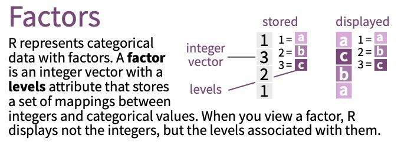

This package allows us to set the **levels** (stored internally as `levels`) that a given categorical variable takes so that no mistakes, errors in data collection and generation can be generated. It also makes their analysis less computationally expensive when doing searches and comparisons, giving them a **different treatment than normal text strings**.

Let’s see a simple example simulating a `party` variable taking the values `"PP"`, `"PSOE"` and `"SUMAR"` (of size 15)

```r
set.seed(1234567)
party <- sample(x = c("PP", "PSOE", "SUMAR"), size = 15, replace = TRUE)
party
```

```
 [1] "PP"    "PSOE"  "SUMAR" "PP"    "PP"    "SUMAR" "PSOE"  "SUMAR" "SUMAR"
[10] "SUMAR" "PP"    "PSOE"  "PP"    "PSOE"  "SUMAR"
```

The `party` variable is currently of **type text**, of type `chr`, something we can check with `class(state)`.

```r
class(party)
```

```
[1] "character"
```

From a statistical and computational point of view, for `R` this variable right now would be equivalent to a named variable. But statistically **a variable as a string** is not the same as a categorical variable that **can only take those 3 levels**. How to **convert to factor**?

By making use of the `as_factor()` function from the `{forcats}` package.

```r
library(tidyverse)
party_fct <- tibble("id" = 1:length(party),
                    "party" = as_factor(party))
party_fct
```

```
# A tibble: 15 × 2
      id party
   <int> <fct>
 1     1 PP
 2     2 PSOE
 3     3 SUMAR
 4     4 PP
 5     5 PP
 6     6 SUMAR
 7     7 PSOE
 8     8 SUMAR
 9     9 SUMAR
10    10 SUMAR
11    11 PP
12    12 PSOE
13    13 PP
14    14 PSOE
15    15 SUMAR
```

Not only the class of the variable has changed, but now, below the saved value, the sentence `Levels: ...` appears: these are the **modalities or levels** of our qualitative.

```r
party_fct |> pull(party)
```

```
 [1] PP    PSOE  SUMAR PP    PP    SUMAR PSOE  SUMAR SUMAR SUMAR PP    PSOE
[13] PP    PSOE  SUMAR
Levels: PP PSOE SUMAR
```

```r
party_fct |>
  filter(party %in% c("PP", "SUMAR")) |>
  pull(party)
```

```
 [1] PP    SUMAR PP    PP    SUMAR SUMAR SUMAR SUMAR PP    PP    SUMAR
Levels: PP PSOE SUMAR
```

With `factor()` function we can **explicitly specify** the names of the modalities and using `levels = ...` we can explicitly tell it the **“order” of the modalities**

```r
party_fct <-
  tibble(id = 1:length(party),
         party = factor(party, levels = c("SUMAR", "PP", "PSOE")))
party_fct |> pull(party)
```

```
 [1] PP    PSOE  SUMAR PP    PP    SUMAR PSOE  SUMAR SUMAR SUMAR PP    PSOE
[13] PP    PSOE  SUMAR
Levels: SUMAR PP PSOE
```

The previous “order” is just in the sense which it will be counted/plotted first) but **we don’t have (yet) an ordinal variable**

```r
party_fct$party < "SUMAR"
```

```
 [1] NA NA NA NA NA NA NA NA NA NA NA NA NA NA NA
```

What if we want to **define a qualitative variable ORDINAL**? Inside `factor()` we must indicate that `ordered = TRUE`.

```r
marks <- c("A", "E", "F", "B", "A+", "A", "C", "C", "D", "B", "A", "C", "C", "E", "F", "D", "A+")
marks_database <-
  tibble("student" = 1:length(marks),
         "marks" =
           factor(marks, levels = c("F", "E", "D", "C", "B", "A", "A+"),
                  ordered = TRUE))
marks_database |> pull(marks)
```

```
 [1] A  E  F  B  A+ A  C  C  D  B  A  C  C  E  F  D  A+
Levels: F < E < D < C < B < A < A+
```

What changes? If you notice now, although the variable is still qualitative, we can **make comparisons and order the records** because there is a **hierarchy** between the modalities.

```r
marks_database |> filter(marks >= "B")
```

```
# A tibble: 7 × 2
  student marks
    <int> <ord>
1       1 A
2       4 B
3       5 A+
4       6 A
5      10 B
6      11 A
7      17 A+
```

If we want to tell it to **drop an unused level** at that moment (and that we want to **exclude from the definition**) we can do it with `fct_drop()`.

```r
marks_database |>
  filter(marks %in% c("F", "E", "D", "C", "B", "A")) |>
  pull(marks)
```

```
 [1] A E F B A C C D B A C C E F D
Levels: F < E < D < C < B < A < A+
```

```r
marks_database |>
  filter(marks %in% c("F", "E", "D", "C", "B", "A")) |>
  mutate(marks = fct_drop(marks)) |>
  pull(marks)
```

```
 [1] A E F B A C C D B A C C E F D
Levels: F < E < D < C < B < A
```

Just as we can delete levels we can **expand existing levels** (even if there is no data for that level at that time) with `fct_expand()`.

```r
marks_database |>
  mutate(marks = fct_expand(marks, c("F-", "A+", "A++"))) %>%
  pull(marks)
```

```
 [1] A  E  F  B  A+ A  C  C  D  B  A  C  C  E  F  D  A+
Levels: F < E < D < C < B < A < A+ < F- < A++
```

In addition with `fct_explicit_na()` we can **assign a level to the missing values** to be included in the analysis and visualizations.

```r
fct_explicit_na(factor(c("a", "b", NA)))
```

```
[1] a         b         (Missing)
Levels: a b (Missing)
```

Even once defined we can **reorder the levels** with `fct_relevel()`.

```r
marks_database_expand <-
  marks_database |>
  mutate(marks = fct_expand(marks, c("F-", "A+", "A++"))) |>
  pull(marks)

marks_database_expand |>
  fct_relevel(c("F-", "F", "E", "D", "C", "B", "A", "A+", "A++"))
```

```
 [1] A  E  F  B  A+ A  C  C  D  B  A  C  C  E  F  D  A+
Levels: F- < F < E < D < C < B < A < A+ < A++
```

This way of working with qualitative variables allows us to give a **theoretical definition** of our database, and we can even count values that do not yet exist (but could), making use of `fct_count()`.

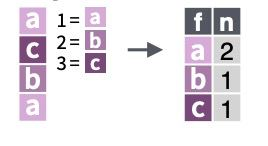

```r
marks_database |>
  mutate(marks = fct_expand(marks, c("F-", "A+", "A++"))) |>
  pull(marks) |>
  fct_count()
```

```
# A tibble: 9 × 2
  f         n
  <ord> <int>
1 F         2
2 E         2
3 D         2
4 C         4
5 B         2
6 A         3
7 A+        2
8 F-        0
9 A++       0
```

The levels can also be **sorted by frequency** with `fct_infreq()`.

```r
marks_database |>
  mutate(marks = fct_infreq(marks)) |>
  pull(marks)
```

```
 [1] A  E  F  B  A+ A  C  C  D  B  A  C  C  E  F  D  A+
Levels: C < A < F < E < D < B < A+
```

```r
marks_database |>
  mutate(marks = fct_infreq(marks)) |>
  pull(marks) |>
  fct_count()
```

```
# A tibble: 7 × 2
  f         n
  <ord> <int>
1 C         4
2 A         3
3 F         2
4 E         2
5 D         2
6 B         2
7 A+        2
```

Sometimes we will want to **group levels**, for example, not allowing levels that **do not happen a minimum number of times** with `fct_lump_min(..., min = ..)` (observations that do not meet this will go to a **generic level** called `Other`, although this can be changed with the `other_level` argument).

```r
marks_database |>
  pull(marks) %>%
  fct_lump_min(min = 3)
```

```
 [1] A     Other Other Other Other A     C     C     Other Other A     C
[13] C     Other Other Other Other
Levels: C < A < Other
```

```r
marks_database |>
  pull(marks) |>
  fct_lump_min(min = 3,
               other_level = "Less frequent")
```

```
 [1] A             Less frequent Less frequent Less frequent Less frequent
 [6] A             C             C             Less frequent Less frequent
[11] A             C             C             Less frequent Less frequent
[16] Less frequent Less frequent
Levels: C < A < Less frequent
```

We can do something equivalent but based on its **relative frequency** with `fct_lump_prop()`.

```r
marks_database |>
  pull(marks) |>
  fct_lump_prop(prop = 0.15,
                other_level = "less frequent")
```

```
 [1] A             less frequent less frequent less frequent less frequent
 [6] A             C             C             less frequent less frequent
[11] A             C             C             less frequent less frequent
[16] less frequent less frequent
Levels: C < A < less frequent
```

We can apply this to our datasets to **recategorize variables** very quickly.

```r
starwars |>
  drop_na(species) |>
  mutate(species =
           fct_lump_min(species, min = 3,
                        other_level = "Others")) |>
  count(species)
```

```
# A tibble: 4 × 2
  species     n
  <fct>   <int>
1 Droid       6
2 Gungan      3
3 Human      35
4 Others     39
```

With `fct_reorder()` we can also indicate that we want to **order the factors** according to a function applied to another variable.

```r
starwars_factor <-
  starwars |>
  drop_na(height, species) |>
  mutate(species =
           fct_lump_min(species, min = 3,
                        other_level = "Others"))
```

```r
starwars_factor |>  pull(species)
```

```
 [1] Human  Droid  Droid  Human  Human  Human  Human  Droid  Human  Human
[11] Human  Human  Others Human  Others Others Human  Others Human  Human
[21] Droid  Others Human  Human  Others Human  Others Others Human  Others
[31] Human  Human  Gungan Gungan Gungan Human  Others Others Human  Human
[41] Others Others Others Others Others Others Others Human  Others Others
[51] Others Others Others Others Others Others Human  Others Others Others
[61] Human  Human  Human  Human  Others Others Others Others Human  Droid
[71] Others Others Others Others Others Human  Others
Levels: Droid Gungan Human Others
```

```r
starwars_factor |>
  mutate(species = fct_reorder(species, height, mean)) |>
  pull(species)
```

```
 [1] Human  Droid  Droid  Human  Human  Human  Human  Droid  Human  Human
[11] Human  Human  Others Human  Others Others Human  Others Human  Human
[21] Droid  Others Human  Human  Others Human  Others Others Human  Others
[31] Human  Human  Gungan Gungan Gungan Human  Others Others Human  Human
[41] Others Others Others Others Others Others Others Human  Others Others
[51] Others Others Others Others Others Others Human  Others Others Others
[61] Human  Human  Human  Human  Others Others Others Others Human  Droid
[71] Others Others Others Others Others Human  Others
Levels: Droid Others Human Gungan
```

### 7.1 💻 It’s your turn

**Exercise 1**

📝 Given the variable `months` defined below (defined as a character vector), convert this variable to factor (just that)

```r
months <- c("Jan", "Feb", "Mar", "Apr")
```

```r
months <- c("Jan", "Feb", "Mar", "Apr")
months_fct <- as_factor(months)
months_fct
```

**Exercise 2**

📝 Given the variable `months` defined below converts this variable to a factor but indicating the levels correctly.

```r
months <- c(NA, "Apr", "Jan", "Oct", "Jul", "Jan", "Sep", NA, "Feb", "Dic",
           "Jul", "Mar", "Jan", "Mar", "Feb", "Apr", "May", "Oct", "Sep",  NA,
           "Dic", "Jul", "Nov", "Feb", "Oct", "Jun", "Sep", "Oct", "Oct", "Sep")
```

```r
months_fct <-
  factor(months,
         levels = c("Jan", "Feb", "Mar", "Apr", "May", "Jun", "Jul", "Aug", "Sep", "Oct", "Nov", "Dic"))
months_fct
```

**Exercise 3**

📝 Count how many values there are for each month but keep in mind that they are factors (maybe there are unused levels and you should get a 0 for them).

```r
meses_fct |>  fct_count()
```

**Exercise 4**

📝 Since there are missing values, it indicates that the absentee is a thirteenth level labeled `"missing"`.

```r
months_fct <-
  months_fct |>
  fct_explicit_na(na_level = "missing")
months_fct
```

**Exercise 5**

📝 Removes unused levels.

```r
months_fct <-
  months_fct %>%
  fct_drop()
months_fct
```

**Exercise 6**

📝 Sort the levels by frequency of occurrence.

```r
months_fct |>
  fct_infreq()
```

**Exercise 7**

📝 Group levels so that any level that does not appear at least 7% of the time is grouped in a level called `"other months"`.

```r
months_fct <-
  months_fct |>
  fct_lump_prop(prop = 0.07, other_level = "other months")
months_fct
```

## 8 🐣 Case study II: CIS survey

[📊 Data](https://drive.google.com/drive/folders/18Ok6Epqcimszqguj_JTTLuSbs5Ot5Srd?usp=sharing)

We are going to work again with file contains data from the CIS (Centro de Investigaciones Sociológicas) barometer «Perceptions on equality between men and women and gender stereotypes» whose sample work was carried out from November 6 to 14 (4000 interviews of both sexes over 16 years old in 1174 municipalities and 50 provinces).

### 8.1 Question 1

> Run the entire code of the previous case study

```r
library(haven)
data <-
  read_sav(file = "./datos/CIS-feminismo/3428.sav") |>
  janitor::clean_names()

rm_variables <-
  data |>
  summarise(across(everything(), n_distinct)) |>
  pivot_longer(cols = everything(), names_to = "variable", values_to = "n_values") |>
  filter(n_values <= 1) |>
  pull(variable)
data <-
  data |>
  select(-rm_variables)

rm_variables <-
  data |>
  summarise(across(everything(), n_distinct)) |>
  pivot_longer(cols = everything(), names_to = "variable", values_to = "n_values") |>
  filter(n_values == nrow(data)) |>
  pull(variable)
data <-
  data |>
  # all of them except one of them
  select(-rm_variables[-1])

data <-
  data |>
  select(-contains("ia_"), -contains("peso"))

population <-
  tibble::tribble(~Total, ~`47.385.107`,
                    "01 Andalucía",   "8.472.407",
                       "02 Aragón",   "1.326.261",
      "03 Asturias, Principado de",   "1.011.792",
               "04 Balears, Illes",   "1.173.008",
                     "05 Canarias",   "2.172.944",
                    "06 Cantabria",     "584.507",
              "07 Castilla y León",   "2.383.139",
         "08 Castilla - La Mancha",   "2.049.562",
                     "09 Cataluña",   "7.763.362",
         "10 Comunitat Valenciana",   "5.058.138",
                  "11 Extremadura",   "1.059.501",
                      "12 Galicia",   "2.695.645",
         "13 Madrid, Comunidad de",   "6.751.251",
            "14 Murcia, Región de",   "1.518.486",
  "15 Navarra, Comunidad Foral de",     "661.537",
                   "16 País Vasco",   "2.213.993",
                    "17 Rioja, La",     "319.796",
                        "18 Ceuta",      "83.517",
                      "19 Melilla",      "86.261"
  )

population <-
  population |>
  rename(ccaa = Total, pop = `47.385.107`) |>
  # First to convert to numeric we need to remove dots
  mutate("pop" = as.numeric(str_replace_all(pop, "\\.", ""))) |>
  # if we use " " as sep, we split also some names
  separate(col = ccaa, into = c("cod_INE", "name"), sep = 2) |>
  # From stringr package, str_squish() removes whitespace at the start
  # and end, and replaces all internal whitespace with a single space.
  mutate(name = str_squish(name))

data <-
  data |>
  # you need first to convert cod_INE as numeric since both
  # key columns should be of same type
  left_join(population |> mutate("cod_INE" = as.numeric(cod_INE)),
            by = c("ccaa" = "cod_INE")) |>
  relocate(name, pop, .after = "ccaa")
```

### 8.2 Question 2

> Notice that many columns are of type `<dbl+lbl>`, a new data type inherited from SPSS to be able to have the numeric value (e.g. `1` for the autonomous community ccaa of Andalusia) but also the label (`«Andalucía»`). You can see more in the `{labelled}` package but for now we are going to use `to_factor()` to be able to work with those labels if we want.

```r
data |>
  # numeric mode
  count(ccaa == 1)
```

```
# A tibble: 2 × 2
  `ccaa == 1`     n
  <lgl>       <int>
1 FALSE        3385
2 TRUE          620
```

```r
data |>
  # labels mode
  count(labelled::to_factor(ccaa) == "Andalucía")
```

```
# A tibble: 2 × 2
  `labelled::to_factor(ccaa) == "Andalucía"`     n
  <lgl>                                      <int>
1 FALSE                                       3385
2 TRUE                                         620
```

> The variables `escfeminis` and `sitconv` actually correspond to question `P16` and `P18` of the questionnaire. Rename them as `p16` and `p18`.

```r
data <-
  data |>
  rename(p16 = escfeminis, p18 = sitconv)
```

### 8.3 Question 3

The variables `tarhogentrev_1`, `tarhogentrev_2`, `tarhogentrev_8`, `tarhogentrev_9`, `tarhogentrev_hh`, `tarhogentrev_mm` refer to the same question: time spent on household chores.

- The variable `tarhogentrev_1` stores a `1` if the respondent answered in hours (otherwise `2`)
- The variable `tarhogentrev_2` stores a `1` if the respondent answered in minutes (otherwise `2`)
- The variable `tarhogentrev_8` stores a `1` if the respondent answered “can’t say” (otherwise `2`)
- The variable `tarhogentrev_9` stores a `1` if the respondent did not want to answer.
- The variables `tarhogentrev_hh` and `tarhogentrev_mm` store the amounts (in hours or minutes, or `99` or `98` if the respondent did not know or did not want to answer).

> Use the information from these 5 variables in such a way that the information is contained in a single variable `p19` with the number of minutes spent (if `NA` cannot be known) and delete all the others

```r
data <-
  data |>
  mutate("p19" =
           if_else(tarhogentrev_1 == 1, tarhogentrev_hh * 60,
                   if_else(tarhogentrev_2 == 1, tarhogentrev_mm, NA)),
         .after = p18) |>
  select(-contains("tarhogentrev"))
```

### 8.4 Question 4

> Perform the same recoding with the variables `tarhogparej_1`, `tarhogparej_2`, `tarhogparej_8`, `tarhogparej_9`, `tarhogparej_hh`, `tarhogparej_mm` (time spent on household chores of the couple) and group their info in `p20`.

```r
data <-
  data |>
  mutate("p20" =
           if_else(tarhogparej_1 == 1, tarhogparej_hh * 60,
                   if_else(tarhogparej_2 == 1, tarhogparej_mm, NA)),
         .after = p19) |>
  select(-contains("tarhogparej"))
```

### 8.5 Question 5

> The variable `hijomenor_1` contains a `1` if it has children and the number of fixed is in `hijomenor_n`; if `hijomenor_97` contains a `1` we should impute `0` in number of children; if `hijomenor_99` is `1` we should impute `NA`. Collects the info of the 4 variables in a single variable called `p21`.

```r
data <-
  data |>
  mutate("p21" =
           if_else(hijomenor_1 == 1, hijomenor_n,
                   if_else(hijomenor_97 == 1, 0, NA)),
         .after = p20) |>
  select(-contains("hijomenor"))
```

### 8.6 Question 6

> The following variables (`cuidadohijos_xxx` and `cuidadohijospar_xxx`) code something similar with respect to time spent on childcare (of the respondent and his/her partner). Summarize the information in two variables `p21a` and `p21b` as we have done with `p19` and `p20`.

```r
data <-
  data |>
  mutate("p21a" =
           if_else(cuidadohijos_1 == 1, cuidadohijos_hh * 60,
                   if_else(cuidadohijos_2 == 1, cuidadohijos_mm, NA)),
         "p21b" =
           if_else(cuidadohijospar_1 == 1, cuidadohijospar_hh * 60,
                   if_else(cuidadohijospar_2 == 1, cuidadohijospar_mm, NA)),
         .after = p21) |>
  select(-contains("cuidadohijos"))
```

### 8.7 Question 7

> Do the same with `tareascuid_xxx` regarding the time spent on care and attention of a sick and/or dependent person in a working day, and store the info in `p22a`. Think that in `p22` is stored if you have a sick or dependent person in your care; if `p22` is `No` (`2`) or `N.C.` (`9`) the value of `p22a` should be `NA`.

```r
data <-
  data |>
  mutate("p22a" =
           if_else(p22 %in% c(2, 9), NA,
                   if_else(tareascui_1 == 1, tareascui_hh * 60,
                           if_else(tareascui_2 == 1, tareascui_mm, NA))),
         .after = p22) |>
  select(-contains("tareascui"))
```

### 8.8 Question 8

> Finally the variables `escideol`, `participaciong`, `recuvotog`, `escuela`, `nivelestentrev`, `religion`, `practicarelig6`, `sitlab`, `relalab`, `cno11`, `tipojor`, `ingreshog`, `clasesocial`, `paisnac`, `paisnac2` should be renamed as `p24`, `p25`, `p25a`, `p26`, `p26a`, `p27`, `p27a`, `p28`, `p28a`, `p28b`, `p28c`, `p29`, `p30`, `p31` and `p31a`. In addition the variable `sinceridad` collects the subjective sincerity that the pollster has perceived in the respondent and the variables `recuvotogr` and `recuerdo` capture vote recall information that we already have collected elsewhere. Rename the former, delete the latter and move the variables `estudios`, `cno11r`, `clasesub` (studies, occupation according to Social Security coding and subjective class identification) before the surveyed questions.

```r
data <-
  data |>
  rename(p24 = escideol, p25 = participaciong, p25a = recuvotog,
         p26 = escuela, p26a = nivelestentrev, p27 = religion,
         p27a = practicarelig6, p28 = sitlab, p28a = relalab,
         p28b = cno11, p28c = tipojor, p29 = ingreshog,
         p30 = clasesocial, p31 = paisnac, p31a = paisnac2) |>
  select(-(sinceridad:recuerdo)) |>
  relocate(estudios, cno11r, clasesub, .before = p0)
data
```

```
# A tibble: 4,005 × 107
   registro ccaa          name     pop prov    mun      capital tamuni  tipo_tel
      <dbl> <dbl+lbl>     <chr>  <dbl> <dbl+l> <dbl+lb> <dbl+l> <dbl+l> <dbl+lb>
 1     2821 1 [Andalucía] Anda… 8.47e6 4 [Alm… 13 [Alm… 2 [Cap… 5 [100… 2 [Móvi…
 2    19046 1 [Andalucía] Anda… 8.47e6 4 [Alm… 13 [Alm… 2 [Cap… 5 [100… 1 [Fijo]
 3    20465 1 [Andalucía] Anda… 8.47e6 4 [Alm… 13 [Alm… 2 [Cap… 5 [100… 2 [Móvi…
 4    31462 1 [Andalucía] Anda… 8.47e6 4 [Alm… 13 [Alm… 2 [Cap… 5 [100… 2 [Móvi…
 5    33504 1 [Andalucía] Anda… 8.47e6 4 [Alm… 13 [Alm… 2 [Cap… 5 [100… 2 [Móvi…
 6    35292 1 [Andalucía] Anda… 8.47e6 4 [Alm… 13 [Alm… 2 [Cap… 5 [100… 2 [Móvi…
 7    37633 1 [Andalucía] Anda… 8.47e6 4 [Alm… 13 [Alm… 2 [Cap… 5 [100… 2 [Móvi…
 8    40018 1 [Andalucía] Anda… 8.47e6 4 [Alm… 13 [Alm… 2 [Cap… 5 [100… 1 [Fijo]
 9    41526 1 [Andalucía] Anda… 8.47e6 4 [Alm… 13 [Alm… 2 [Cap… 5 [100… 2 [Móvi…
10    62946 1 [Andalucía] Anda… 8.47e6 4 [Alm… 13 [Alm… 2 [Cap… 5 [100… 1 [Fijo]
# ℹ 3,995 more rows
# ℹ 98 more variables: sexo <dbl+lbl>, edad <dbl+lbl>, estudios <dbl+lbl>,
#   cno11r <dbl+lbl>, clasesub <dbl+lbl>, p0 <dbl+lbl>, p1 <dbl+lbl>,
#   p2 <dbl+lbl>, p3_1 <dbl+lbl>, p3_2 <dbl+lbl>, p3_3 <dbl+lbl>,
#   p3_4 <dbl+lbl>, p3_5 <dbl+lbl>, p4 <dbl+lbl>, p5 <dbl+lbl>, p6_1 <dbl+lbl>,
#   p6_2 <dbl+lbl>, p6_3 <dbl+lbl>, p7_1 <dbl+lbl>, p7_2 <dbl+lbl>,
#   p7_3 <dbl+lbl>, p7_4 <dbl+lbl>, p7_5 <dbl+lbl>, p7_6 <dbl+lbl>, …
```

### 8.9 Question 9

Note that there are variables in the questionnaire, such as `p0` and `p1`, that although they are coded numerically, in reality we should have them only qualitatively. For example, if you look at the questionnaire, the variable `p0` corresponds to the question `P0.c` which says “First of all I would like to ask you if you have…

- Spanish nationality –> 1
- Spanish nationality and other –> 2
- Other nationality –> 3

```r
data |> count(p0)
```

```
# A tibble: 3 × 2
  p0                                      n
  <dbl+lbl>                           <int>
1 1 [La nacionalidad española]         3711
2 2 [La nacionalidad española y otra]   151
3 3 [Otra nacionalidad]                 143
```

If we were to leave the variable as it is, numerically, we would be assuming two incorrect things:

1. There is a hierarchy (having Spanish nationality is better or worse than having another nationality).
2. This hierarchy is also quantified numerically: since 2 is double 1, it implies that, in some way, having two nationalities is “twice as much” as having only Spanish nationality

If you look at the questionnaire, all the variables that are `p{number}` (without the low slash `_`) are of this type. The others respond to a more complex questionnaire (a series of questions to be assessed on a scale that is qualitative ordinal and we will consider that it can be converted to an ordinal factor).

> Convert the `p{number}` to qualitative (nominal) with its label and the `p{number}_x` to ordinal qualitative (with its number). In the latter, note that “don’t know/no answer” responses are coded as `98` and `99` (and should be NA).

```r
library(labelled)
data <-
  data |>
  # with $ to specify "not more than..."
  mutate(across(matches("p[0-9]{1}$|p[0-9]{2}$"), to_factor),
         across(matches("p[0-9]{1}_|p[0-9]{2}_"),
                function(x) { factor(if_else(x %in% c(98, 99), NA, x),
                                     ordered = TRUE) } ))
```

> In some compound questions with only 5 options, the `NA` are coded as `7`, `8` or `9`.

```r
data <-
  data |>
  # with $ to specify "not more than..."
  mutate(across(matches("p[0-9]{1}_|p[0-9]{2}_"),
                function(x) { factor(if_else(x %in% c(7, 8, 9), NA, x),
                                     ordered = TRUE) } ))
```

### 8.10 Question 10

> Calculate a two-dimensional table of relative frequencies between the variable `sex` and the variable `p4` (degree of inequality between men and women in Spain) normalizing as you consider to answer the following question: what percentage of women believe that inequalities are very large or quite large? And of men?

```r
table_freq <- table(to_factor(data$sexo), data$p4)
prop.table(table_freq, margin = 1)
# 67% of women
# 48.7% of men
```

### 8.11 Question 11

> Calculate a measure of association between these variables and detail conclusions.

```r
data |>
  summarise("sig_chisq" = chisq.test(to_factor(sexo), p4)$p.value)
# tiny p-valor --> enough evidences againts null hyp -->
# answers to p4 depends on sex
```

### 8.12 Question 12

> Create a simple graph in `ggplot()` that allows to represent the variable `p4` in function of sexes, allowing to appreciate the differences in them.

```r
# first option: geom_bar with abs freqs
ggplot(data |>
         mutate("sexo" = to_factor(sexo))) +
  geom_bar(aes(x = p4, fill = p4), alpha = 0.7) +
  ggthemes::scale_fill_colorblind() +
  facet_wrap(~sexo) +
  theme_minimal()

# second option: geom_col with rel freqs
ggplot(data |>
         mutate("sexo" = to_factor(sexo)) |>
         count(sexo, p4) |>
         mutate("porc" = n/sum(n))) +
  geom_col(aes(x = p4, y = porc, fill = p4), alpha = 0.7) +
  scale_y_continuous(labels = scales::label_percent()) +
  ggthemes::scale_fill_colorblind() +
  facet_wrap(~sexo) +
  theme_minimal()

# third option: horizontal bars
ggplot(data |>
         mutate("sexo" = to_factor(sexo)) |>
         count(sexo, p4) |>
         mutate("porc" = n/sum(n)) |>
         mutate("porc" = if_else(sexo == "Hombre", -porc, porc))) +
  geom_col(aes(y = p4, x = porc, fill = p4), alpha = 0.7) +
  scale_x_continuous(labels = scales::label_percent()) +
  ggthemes::scale_fill_colorblind() +
  facet_wrap(~sexo, scales = "free_x") +
  theme_minimal()

# fourth option: fill geom bar
ggplot(data |>
         mutate("sexo" = to_factor(sexo))) +
  geom_bar(aes(x = sexo, fill = p4), position = "fill",
           alpha = 0.7) +
  ggthemes::scale_fill_colorblind() +
  theme_minimal()
```

### 8.13 Question 13

> Performs the same analysis but regroups `p4` earlier into only 3 levels: grandes (`Muy grandes` and `Bastante grandes`), pequeñas (`Pequeñas` and `Casi inexistentes`) and `NS/NC`.

```r
data <-
  data |>
  mutate("p4" =
           fct_collapse(data$p4,
                        "grandes" = c("Muy grandes", "Bastante grandes"), "NS/NC" = c("N.S.", "N.C."),
                        other_level = "pequeñas"))

table_freq <- table(to_factor(data$sexo), data$p4)
prop.table(table_freq, margin = 1)
# 67% of women
# 48.7% of men

data |>
  summarise("sig_chisq" = chisq.test(to_factor(sexo), p4)$p.value)

ggplot(data |>
         mutate("sexo" = to_factor(sexo))) +
  geom_bar(aes(x = sexo, fill = p4), position = "fill",
           alpha = 0.7) +
  ggthemes::scale_fill_colorblind() +
  theme_minimal()
```

### 8.14 Question 14

> Question `p16` captures, on a scale of 0 to 10 (where 0 means “not at all feminist” and 10 means “very feminist”) the self-placement of the respondents. How is this variable distributed by gender? Make a frequency table

```r
prop.table(table(to_factor(data$sexo), data$p16), margin = 1)
```

```r
data |>
  mutate("p16" = factor(p16, ordered = TRUE)) |>
  group_by(sexo) |>
  count(p16 > 7) |>
  mutate("porc" = 100*n/sum(n)) |>
  ungroup()
# 48.3% between men
# 62.3% between women
```

> Question `p19` captured minutes spent on household chores. Converts to numeric (“No minutes” as 0).

```r
data <-
  data |>
  mutate("p19" = as.numeric(as.character(p19)))
```

> After that, first calculate the average by sex disaggregated, and then the average disaggregated by sex and `p16`. What conclusions do you draw? Make a graph if you consider it

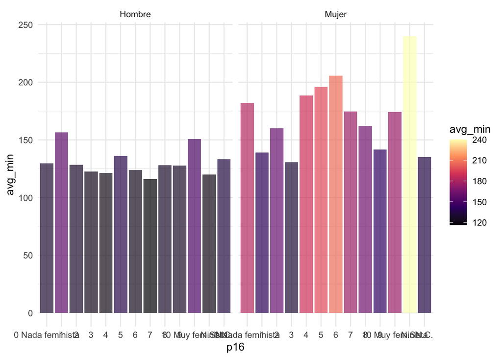

```r
mean_sex <-
  data |>
  summarise("avg_min" = mean(p19, na.rm = TRUE), .by = sexo)
# 175 minutes in women vs 129 in men

mean_sex_feminism <-
  data |>
  summarise("avg_min" = mean(p19, na.rm = TRUE),
            .by = c(sexo, p16))
ggplot(mean_sex_feminism) +
  geom_col(aes(x = p16, y = avg_min, fill = avg_min),
           alpha = 0.7) +
  scale_fill_viridis_c(option = "magma") +
  facet_wrap(~to_factor(sexo)) +
  theme_minimal()
```

```r
# We can see how in men the average minutes remains cte
# without depending on the self-localization in the
# feminism scale
```

### 8.15 Question 15

> We will calculate in a new variable the difference in minutes spent at home between the respondent (`p19`) and his/her partner (`p20`).

```r
data <-
  data |>
  mutate("p20" = as.numeric(as.character(p20))) |>
  mutate("diff_min" = p19 - p20)
```

> Repeat the previous analysis using this difference in minutes.

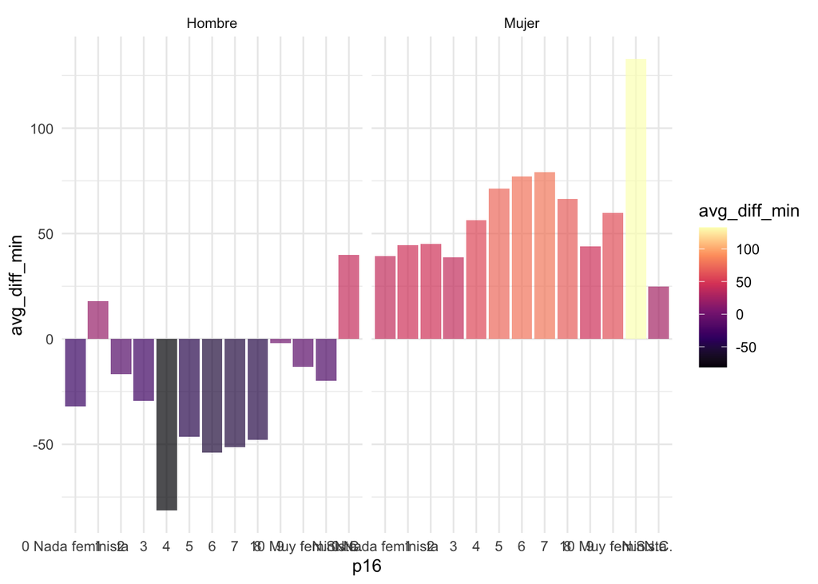

```r
mean_sex <-
  data |>
  filter(p17a %in% c(1, 2) & as.numeric(p17a) != as.numeric(sexo)) |>
  summarise("avg_diff_min" = mean(diff_min, na.rm = TRUE), .by = sexo)
# +63.7 minutes in women vs -40.6 in men

mean_sex_feminism <-
  data |>
  filter(p17a %in% c(1, 2) & as.numeric(p17a) != as.numeric(sexo)) |>
  summarise("avg_diff_min" = mean(diff_min, na.rm = TRUE),
            .by = c(sexo, p16))

ggplot(mean_sex_feminism) +
  geom_col(aes(x = p16, y = avg_diff_min, fill = avg_diff_min),
           alpha = 0.7) +
  scale_fill_viridis_c(option = "magma") +
  facet_wrap(~to_factor(sexo)) +
  theme_minimal()
```